# Graph Neural Networks for the Quantum Approximate Optimization Algorithm (QAOA)

**Integrated Analysis: GNN-Based QAOA Parameter Prediction and Network-Based Biomedical Graph Modeling**

## Research Overview

This notebook presents an integrated view of the **Graph Neural Networks for the Quantum Approximate Optimization Algorithm (QAOA)** research program, placing two empirical applications under a common graph-to-parameterization framework.

The **primary contribution** is the development of GNN methods to improve the performance, parameter selection, and scalability of QAOA by addressing the central bottleneck of classical parameter optimization in hybrid quantum-classical combinatorial optimization. Structured graph optimization problems are used to train GNN models capable of predicting QAOA parameterizations, approximation ratios, and convergence behavior, incorporating graph topology, Hamiltonian structure, and symmetry properties into the learned pipeline. Performance is evaluated through held-out benchmarking, transferability testing across graph families, and robustness analysis under noise.

Improving QAOA in this setting also strengthens computational tools relevant to **artificial intelligence and network-based biomedical systems** — demonstrated here through a companion clinical graph application.

The **companion application** shows that the same GNN methodology extends to cardiotocography patient-similarity graphs, where node-level pathologic-risk scores serve as the learned decision variables. This connection reflects the broader applicability of the research framework.

## Scope

This notebook places two empirical settings under the same interface: transcriptomic co-expression graphs mapped to depth-2 Quantum Approximate Optimization Algorithm (QAOA) angle vectors, and cardiotocography (CTG) patient-similarity graphs mapped to pathologic-risk scores. The comparison is organized around the emitted parameterization and its downstream evaluation rather than around a shared loss or shared model family.

## System View

| Branch | Input graph | Learned parameterization | Downstream objective |
| --- | --- | --- | --- |
| Transcriptomic QAOA (primary) | gene co-expression graph | depth-2 angle vector $(\gamma_1, \gamma_2, \beta_1, \beta_2)$ | expected maximum cut (MaxCut) value |
| Cardiotocography (CTG) screening | patient-similarity graph | node-level pathologic-risk scores | thresholded screening behavior |

## Key Results

[output not shown]

## Navigation

- Start with the integrated figure gallery.
- Then use the comparative table to separate shared structure from domain-specific evaluation.
- Read the notebook as an interface study spanning two downstream objectives.

## Statistical Comparison: This Work vs. All Prior Methods

> **Read this first.** Both branches of this research are benchmarked against every comparable method on identical held-out evaluation sets. The tables below show exact numbers, improvement deltas, and the statistical case for each contribution.

### Branch 1 — QAOA Parameter Prediction (held-out approximation ratio, higher = better)

[output not shown]

### Branch 2 — CTG Clinical Risk Scoring (held-out, n = 426 exams, 35 pathologic)

| Method | Accuracy | Balanced Acc. | ROC AUC | TP / 35 | FP |
| --- | --- | --- | --- | --- | --- |
| Logistic Regression | 94.1% | 0.916 | 0.984 | 31 | 21 |
| Random Forest | 96.9% | 0.905 | 0.994 | 29 | 7 |
| MLP (tabular neural net) | 98.4% | 0.926 | 0.971 | 30 | 2 |
| LightGBM | 98.6% | 0.927 | 0.993 | 30 | 1 |
| XGBoost | 98.8% | 0.955 | 0.992 | 32 | 2 |
| Calibrated LightGBM (strongest tabular) | **99.1%** | **0.956** | 0.991 | 32 | 1 |
| AdaptiveBioGCN (graph, this work) | 96.7% ± 0.97% | — | — | — | — |
| ⭐ **ResidualClinicalGCN (graph, this work)** | **98.8%** | **0.942** | **0.978** | **31** | **1** |

## Comparative View

The two settings differ in objective, supervision, and evaluation, but they share the same graph-to-parameterization pattern. The table below is the organizing comparison used throughout the project materials.

| Setting | Input graph | Parameterization | Downstream objective | Main metrics |
| --- | --- | --- | --- | --- |
| Transcriptomic Quantum Approximate Optimization Algorithm (QAOA) | gene co-expression graph | depth-2 angle vector $(\gamma_1, \gamma_2, \beta_1, \beta_2)$ | expected maximum cut (MaxCut) value | approximation ratio, runtime, regret |
| Cardiotocography (CTG) screening | patient-similarity graph | node-level pathologic-risk scores | thresholded screening behavior | accuracy, balanced accuracy, receiver operating characteristic area under the curve (ROC AUC), operating point |

The comparison isolates the shared interface claim without obscuring that the two branches solve different tasks.

## Signal Gallery

These figures summarize the main evidence before the implementation cells. Later sections reconstruct the same outputs from executable code for each branch.

### Transcriptomic Adaptation and Benchmark

[figure not shown]

### Integrated Biomedical Evaluation

[figure not shown]

### Fixed-Split Robustness

[figure not shown]

## 0. Theoretical Foundation

### 0.1 Quantum Approximate Optimization Algorithm (QAOA): Formalism and Guarantees

**Problem statement.** Maximum cut (MaxCut) on graph $G=(V,E)$ asks for a bipartition $(S, \bar S)$ maximizing $\lvert\{(u,v)\in E : u\in S, v\notin S\}\rvert$. It is NP-hard in general; the best classical polynomial-time approximation guarantee is $0.878$ (Goemans–Williamson, 1995).

**Cost Hamiltonian.** Encode the cut value as the diagonal operator

$$\hat{C} = \frac{1}{2}\sum_{(u,v)\in E}\!\left(I - Z_u \otimes Z_v\right),$$

where $Z_i = \sigma_z$ acts on qubit $i$. For a computational basis state $|x\rangle$ encoding partition $x\in\{0,1\}^n$, $\hat{C}|x\rangle = c(x)|x\rangle$ where $c(x)$ counts edges crossing the cut.

**Variational ansatz.** The depth-$p$ QAOA state is

$$|\boldsymbol\gamma, \boldsymbol\beta\rangle = \prod_{k=1}^{p} e^{-i\beta_k \hat{B}}\, e^{-i\gamma_k \hat{C}} |+\rangle^{\otimes n},$$

where $\hat{B} = \sum_i X_i$ is the transverse-field mixer and $|+\rangle^{\otimes n} = H^{\otimes n}|0\rangle^{\otimes n}$ is the uniform superposition.

**Objective.** Maximize

$$\mathcal{F}(\boldsymbol\gamma, \boldsymbol\beta) = \langle\boldsymbol\gamma,\boldsymbol\beta|\hat{C}|\boldsymbol\gamma,\boldsymbol\beta\rangle.$$

At $p=1$ this is a smooth function of 2 real parameters, and maximizers are accessible via standard gradient-free methods (Nelder–Mead, COBYLA) since the function landscape is benign for small $n$.

**Depth-1 closed form.** For $p=1$ one can derive:

$$\mathcal{F}(\gamma,\beta) = \frac{1}{2}\sum_{(u,v)\in E}\left[\sin(2\beta)\sin(\gamma)\Delta_{uv}(\gamma) - \ldots \right],$$

where the per-edge contributions depend on the local neighborhood structure. The exact formula is graph-dependent; this notebook evaluates $\mathcal{F}$ numerically via statevector simulation, which is exact for $n \le 25$.

**Approximation ratio (AR).** We define

$$r = \frac{\mathcal{F}(\gamma^*, \beta^*)}{C^*} \in [0, 1],$$

where $C^* = \max_x c(x)$ is the exact MaxCut value. Farhi et al. (2014) show that even $p=1$ QAOA achieves $r \ge 0.6924$ on 3-regular graphs; practical ratios on random instances are typically higher.

### 0.2 Graph Convolutional Network (GCN): Message Passing and Spectral Motivation

**Kipf–Welling Graph Convolutional Network (GCN) (2017).** Given augmented adjacency $\hat{A} = A + I_n$ and degree matrix $\hat{D}_{ii} = \sum_j \hat{A}_{ij}$, the propagation rule is

$$H^{(l+1)} = \sigma\!\left(\hat{D}^{-1/2}\hat{A}\hat{D}^{-1/2}\,H^{(l)}\,W^{(l)}\right).$$

Spectral motivation: $\hat{D}^{-1/2}\hat{A}\hat{D}^{-1/2}$ is the normalized Laplacian smoother; it implements a first-order Chebyshev approximation to spectral convolution on the graph.

**Global graph representation.** After $L$ layers, aggregate node embeddings to a single graph-level vector via mean-pooling:

$$\mathbf{z}_G = \frac{1}{|V|}\sum_{i\in V} H^{(L)}_i.$$

A linear head then maps $\mathbf{z}_G \mapsto (\hat\gamma, \hat\beta)$.

### 0.3 Hybrid Loop: Classical Orchestration + Quantum-Style Evaluation

```
┌──────────────────────────────────────────────────────────────────┐
│  Graph G = (V, E)                                                │
│  ┌───────────────┐         ┌──────────────────────────────────┐  │
│  │  Graph neural │  (γ̂,β̂)  │  QAOA (depth p=1)               │  │
│  │  network      │──────►  │  e^{-iγC} e^{-iβB} |+⟩^⊗n      │  │
│  │  (GNN) warm   │         │  → compute ⟨C⟩                    │  │
│  │  start (O(1)) │         └────────────────┬─────────────────┘  │
│  └───────────────┘                          │                    │
│                                             │ score              │
│  ┌──────────────────────────────────────┐   │                    │
│  │  Classical optimizer (Nelder–Mead)  │◄──┘                    │
│  │  update (γ,β) to improve ⟨C⟩        │                        │
│  └──────────────────────────────────────┘                        │
└──────────────────────────────────────────────────────────────────┘
```

The graph neural network (GNN) provides a **warm start** that initializes the classical optimizer closer to the optimum, potentially reducing the number of function evaluations. This is the core practical claim of the quantum branch.

### 0.4 Transductive Graph Classification (Biomedical Branch)

The biomedical branch uses the same GCN backbone in a different regime:

The key distinction from i.i.d. classification: the prediction for exam $i$ depends on the features and labels of neighboring exams, respecting physiological similarity structure.

### 0.5 Execution Environment

### Step 0 — Environment, Reproducibility, and Audit

The next cell establishes a fully reproducible execution context:

- resolves the project root by walking the directory tree for `/src`,
- pins the global random seed for NumPy, PyTorch, and Python's `random`,
- applies a publication-grade Matplotlib style with consistent DPI and axis formatting,
- and prints a version audit trail for traceability.

> All numerical results downstream are conditioned on `SEED = 42`. Changing this seed will alter transcriptomic resampling, GNN initialization, and train/validation/test splits, but the methodology remains identical.

```python
# ═══════════════════════════════════════════════════════════════════════════════

# CELL 0 — Environment, reproducibility, and version audit

# ═══════════════════════════════════════════════════════════════════════════════



import sys, os, random, time, warnings

from pathlib import Path

warnings.filterwarnings('ignore')



os.environ.setdefault('OMP_NUM_THREADS', '1')

os.environ.setdefault('OPENBLAS_NUM_THREADS', '1')

os.environ.setdefault('MKL_NUM_THREADS', '1')



# ── Resolve project root: walk upward until a /src directory is found ─────────

proj_root = os.path.abspath('..')

if not os.path.isdir(os.path.join(proj_root, 'src')):

    p = os.getcwd()

    while True:

        if os.path.isdir(os.path.join(p, 'src')):

            proj_root = p

            break

        parent = os.path.dirname(p)

        if parent == p:

            proj_root = os.getcwd()

            break

        p = parent



if proj_root not in sys.path:

    sys.path.insert(0, proj_root)



active_conda_env = os.environ.get('CONDA_DEFAULT_ENV', '')

python_executable = Path(sys.executable).resolve()

if active_conda_env == 'qaoa':

    environment_label = 'conda:qaoa'

else:

    environment_label = f'python:{python_executable}'

    print('Warning: expected the qaoa conda environment.')

    print('The notebook will continue because the active kernel may already satisfy the dependencies.')



# ── Core scientific stack ──────────────────────────────────────────────────────

import numpy as np

import torch

import torch.nn.functional as F

import pandas as pd

import matplotlib

import matplotlib.pyplot as plt

import networkx as nx



# ── Project modules ────────────────────────────────────────────────────────────

from src.gnn import SimpleGCN, PYG_AVAILABLE

from src.notebook_export import export_notebook_html as export_notebook_html_artifact



# ── Global random seed (pins NumPy, PyTorch, and Python random) ───────────────

SEED = 42

random.seed(SEED)

np.random.seed(SEED)

torch.manual_seed(SEED)

torch.set_num_threads(max(1, min(4, os.cpu_count() or 1)))

if torch.cuda.is_available():

    torch.cuda.manual_seed_all(SEED)



# ── Matplotlib: publication-grade style ───────────────────────────────────────

plt.style.use('seaborn-v0_8-whitegrid')

plt.rcParams.update({

    'figure.dpi': 130,

    'axes.titlesize': 13,

    'axes.labelsize': 11,

    'axes.spines.top': False,

    'axes.spines.right': False,

    'legend.frameon': False,

    'font.family': 'DejaVu Sans',

    'lines.linewidth': 2.0,

    'xtick.labelsize': 9,

    'ytick.labelsize': 9,

})



# ── Output and export directories ─────────────────────────────────────────────

out_dir = os.path.join(proj_root, 'outputs')

os.makedirs(out_dir, exist_ok=True)

notebook_path = Path(proj_root) / 'notebooks' / 'quantum_ai_bio_combined.ipynb'

notebook_figure_dir = Path(proj_root) / 'notebooks' / 'figures'

html_output_dir = Path(proj_root) / 'website' / 'notebooks_html'

html_figure_dir = html_output_dir / 'figures'

for figure_dir in (notebook_figure_dir, html_figure_dir):

    figure_dir.mkdir(parents=True, exist_ok=True)





def save_notebook_figure(fig, figure_name, dpi=180):

    saved_paths = []

    for figure_path in (notebook_figure_dir / figure_name, html_figure_dir / figure_name):

        fig.savefig(figure_path, dpi=dpi, bbox_inches='tight')

        saved_paths.append(figure_path)

    print(f"Saved figure assets -> {saved_paths[0]}")

    print(f"                     -> {saved_paths[1]}")





def export_notebook_html(output_name='quantum_ai_bio_combined.html'):

    export_script = Path(proj_root) / 'scripts' / 'export_notebook_html.py'

    export_cmd = [

        sys.executable,

        str(export_script),

        str(notebook_path),

        '--output',

        output_name,

        '--output-dir',

        str(html_output_dir),

    ]

    print('export helper:')

    print('  ' + ' '.join(export_cmd))

    output_path = export_notebook_html_artifact(

        notebook_path=notebook_path,

        output_name=output_name,

        output_dir=html_output_dir,

    )

    print(f'Exported HTML: {output_path}')

    return output_path



# ── Hardware audit ────────────────────────────────────────────────────────────

device_str = 'cuda' if torch.cuda.is_available() else 'cpu'



# ── Print audit trail ─────────────────────────────────────────────────────────

sep = '=' * 72

print(sep)

print('  Hybrid Quantum-Classical Pipeline — Execution Audit')

print(sep)

print(f'  Project root     : {proj_root}')

print(f'  Environment      : {environment_label}')

print(f'  Python           : {sys.version.split()[0]}')

print(f'  NumPy            : {np.__version__}')

print(f'  PyTorch          : {torch.__version__}  ({device_str})')

print(f'  NetworkX         : {nx.__version__}')
```

[output not shown]

## Part 2 — Real Transcriptomic Optimization Setting

### 1.1 Why the Optimization Branch Was Rebuilt

The optimization branch now uses the **OpenML `prostate` transcriptomic cohort** rather than a synthetic Erdős–Rényi graph. The workflow loads a cached **top-32 variance-ranked panel**, builds a full-cohort Pearson co-expression graph from a configurable execution subset, and then derives additional **patient-resampled transcriptomic graphs** for adaptation and held-out evaluation.

### 1.2 Why This Is a Stronger Optimization Setting

The previous combined notebook was useful as a live walk-through, but it did not support a strong real-data claim. This refactored branch now does four things that materially raise the evidence standard:

1. uses **real transcriptomic measurements** rather than a synthetic graph family,
2. solves **depth-2 exact QAOA** instead of a lighter toy setup,
3. trains the graph model on **separate transcriptomic resamples** rather than relying on out-of-domain transfer,
4. evaluates on **held-out real-data graphs** with exact MaxCut references.

### 1.3 Optimization Protocol

This stage establishes the transcriptomic benchmark end to end: exact depth-2 MaxCut references are computed, the reduced prostate panel is loaded from cache or fetched on demand, representative and resampled graph families are constructed, the legacy checkpoint is retained for contrast when available, and the representative full-cohort graph is paired with its exact classical reference.

### 1.4 Why the Small-Graph Regime Is Still Legitimate

Exact statevector QAOA is exponential in the number of qubits. The notebook therefore defaults to a **16-gene / 16-qubit execution panel** drawn from a broader cached ranking so every claim remains fully auditable against exact MaxCut and exact expected cut. The scientific point is not large-scale hardware advantage; it is whether a learned graph model can recover near-classical optimization quality on **real biological graphs** in a bounded regime where exact references still exist.

Empirically, the expanded real-data sweep suggests treating **6 to 14 genes** as the main comparison band for the method claim, while **16 genes** is better interpreted as a stress-test edge case where exact auditing remains possible but both cheap initializers degrade more noticeably.

```python
# ═══════════════════════════════════════════════════════════════════════════════
# CELL 2 — Real transcriptomic benchmark setup (OpenML prostate cohort)
# ═══════════════════════════════════════════════════════════════════════════════

from pathlib import Path
import copy
import json
import math

import torch.optim as optim
from scipy.optimize import minimize
from sklearn.datasets import fetch_openml

QAOA_DEPTH = 2
LEGACY_DEPTH = 1
GENE_COUNT = 16
CACHE_DEFAULT_GENE_COUNT = 32
TARGET_EDGE_COUNT = 18
ADAPT_GRAPH_COUNT = 24
BENCHMARK_GRAPH_COUNT = 6
SUBSAMPLE_SIZE = 60

CACHE_PANEL_PATH = os.path.join(proj_root, "data", "prostate_top32_variance_panel.csv.gz")
CACHE_META_PATH = os.path.join(proj_root, "data", "prostate_top32_variance_panel_meta.json")
LEGACY_CACHE_PANEL_PATH = os.path.join(proj_root, "data", "prostate_top10_variance_panel.csv.gz")
LEGACY_CACHE_META_PATH = os.path.join(proj_root, "data", "prostate_top10_variance_panel_meta.json")
OUTPUT_GRAPH_PATH = os.path.join(proj_root, "outputs", "maxcut_graph.csv")
OUTPUT_ANGLES_PATH = os.path.join(proj_root, "outputs", "qaoa_classical_angles.csv")


def resolve_transcriptomic_cache_paths(preferred_panel_path=CACHE_PANEL_PATH, preferred_meta_path=CACHE_META_PATH):
    candidate_pairs = [(preferred_panel_path, preferred_meta_path)]
    if (preferred_panel_path, preferred_meta_path) != (LEGACY_CACHE_PANEL_PATH, LEGACY_CACHE_META_PATH):
        candidate_pairs.append((LEGACY_CACHE_PANEL_PATH, LEGACY_CACHE_META_PATH))

    for panel_path, meta_path in candidate_pairs:
        if os.path.exists(panel_path) and os.path.exists(meta_path):
            return panel_path, meta_path
    return preferred_panel_path, preferred_meta_path


def build_cut_diagonal(n, edges):
    cut_diagonal = np.zeros(2 ** n, dtype=np.float64)
    for state_index in range(2 ** n):
        bits = [(state_index >> bit) & 1 for bit in range(n)]
        cut_diagonal[state_index] = sum(bits[u] != bits[v] for u, v in edges)
    return cut_diagonal


def apply_rx_all(state, n, beta):
    rx = np.array(
        [
            [np.cos(beta), -1j * np.sin(beta)],
            [-1j * np.sin(beta), np.cos(beta)],
        ],
        dtype=np.complex128,
    )
    psi = state.reshape((2,) * n)
    for axis in range(n):
        psi = np.moveaxis(psi, axis, 0)
        psi = np.tensordot(rx, psi, axes=([1], [0]))
        psi = np.moveaxis(psi, 0, axis)
    return psi.reshape(-1)


def qaoa_state_fast(cut_diagonal, gammas, betas):
    num_states = cut_diagonal.shape[0]
    n_qubits = int(np.log2(num_states))
    state = np.ones(num_states, dtype=np.complex128) / np.sqrt(num_states)
    for gamma, beta in zip(gammas, betas):
        state = state * np.exp(-1j * gamma * cut_diagonal)
        state = apply_rx_all(state, n_qubits, beta)
    return state


def expected_cut_fast(cut_diagonal, state):
    return float(np.dot(cut_diagonal, np.abs(state) ** 2))


def brute_force_maxcut(n, edges):
    best_cut = -1
    best_mask = 0
    for mask in range(1, 2 ** n):
        cut_value = sum(1 for u, v in edges if ((mask >> u) & 1) != ((mask >> v) & 1))
        if cut_value > best_cut:
            best_cut = cut_value
            best_mask = mask
    return best_cut, best_mask


def normalize_angles(raw_angles, p):
    raw_angles = np.asarray(raw_angles, dtype=np.float64).reshape(-1)
    gammas = np.mod(raw_angles[:p], math.pi)
    betas = np.mod(raw_angles[p : 2 * p], math.pi / 2)
    return gammas, betas


def qaoa_value_for_angles(cut_diagonal, gammas, betas):
    state = qaoa_state_fast(cut_diagonal, gammas, betas)
    return expected_cut_fast(cut_diagonal, state), state


def classical_optimize_instance(instance, p, num_starts=8, maxiter=320, seed=0):
    cut_diagonal = instance["cut_diagonal"]
    rng = np.random.default_rng(seed)
    best = None

    def objective(x):
        gammas, betas = normalize_angles(x, p)
        value, _ = qaoa_value_for_angles(cut_diagonal, gammas, betas)
        return -value

    for _ in range(num_starts):
        x0 = np.concatenate(
            [
                rng.uniform(0.0, math.pi, size=p),
                rng.uniform(0.0, math.pi / 2, size=p),
            ]
        )
        result = minimize(
            objective,
            x0,
            method="Nelder-Mead",
            options={"maxiter": maxiter, "xatol": 1e-6, "fatol": 1e-6},
        )
        gammas, betas = normalize_angles(result.x, p)
        value, state = qaoa_value_for_angles(cut_diagonal, gammas, betas)
        candidate = {
            "gammas": gammas,
            "betas": betas,
            "value": value,
            "state": state,
            "nit": result.nit,
            "nfev": result.nfev,
            "success": bool(result.success),
            "raw_angles": np.concatenate([gammas, betas]),
        }
        if best is None or candidate["value"] > best["value"]:
            best = candidate
    return best


def predict_instance_with_gnn(instance, model, p):
    adjacency_tensor = torch.tensor(instance["adjacency"], dtype=torch.float32)
    feature_tensor = torch.tensor(instance["features"], dtype=torch.float32)

    with torch.no_grad():
        _ = model(feature_tensor, adjacency_tensor)

    start_time = time.perf_counter()
    with torch.no_grad():
        raw_output = model(feature_tensor, adjacency_tensor).view(-1).cpu().numpy()
    inference_time = time.perf_counter() - start_time

    gammas, betas = normalize_angles(raw_output, p)
    value, state = qaoa_value_for_angles(instance["cut_diagonal"], gammas, betas)
    return {
        "gammas": gammas,
        "betas": betas,
        "value": value,
        "state": state,
        "inference_time": inference_time,
        "raw_output": raw_output,
    }


def load_transcriptomic_panel(cache_panel_path=CACHE_PANEL_PATH, cache_meta_path=CACHE_META_PATH):
    selected_panel_path, selected_meta_path = resolve_transcriptomic_cache_paths(cache_panel_path, cache_meta_path)
    if os.path.exists(selected_panel_path):
        panel_df = pd.read_csv(selected_panel_path, compression="gzip")
        meta = {}
        if os.path.exists(selected_meta_path):
            with open(selected_meta_path, "r", encoding="utf-8") as handle:
                meta = json.load(handle)
        gene_table = pd.DataFrame(meta.get("gene_table", []))
        if not gene_table.empty and "rank" in gene_table.columns:
            gene_table = gene_table.sort_values("rank").reset_index(drop=True)
        if not gene_table.empty:
            gene_names = gene_table["gene"].tolist()[:GENE_COUNT]
        else:
            gene_names = [column for column in panel_df.columns if not column.startswith("__")][:GENE_COUNT]
        labels = pd.Series(panel_df.pop("__target__").astype(str), name=meta.get("label_name", "class"))
        sample_ids = panel_df.pop("__sample_id__").astype(str)
        panel_df.index = sample_ids
        labels.index = sample_ids
        meta["cache_panel_path"] = selected_panel_path
        meta["cache_meta_path"] = selected_meta_path
        meta["cached_gene_count"] = int(meta.get("top_gene_count", len([column for column in panel_df.columns])))
        return panel_df[gene_names], labels, gene_names, meta
```

```python
    dataset = fetch_openml(name="prostate", version=1, as_frame=True)
    expression_frame_full = dataset.data.apply(pd.to_numeric, errors="coerce")
    expression_frame_full = expression_frame_full.loc[:, expression_frame_full.notna().all(axis=0)]
    labels = pd.Series(dataset.target, name=dataset.target_names[0] if dataset.target_names else "class")
    variances = expression_frame_full.var(axis=0).sort_values(ascending=False)
    gene_names = variances.head(max(GENE_COUNT, CACHE_DEFAULT_GENE_COUNT)).index.tolist()
    labels.index = expression_frame_full.index
    panel_meta = {
        "dataset_name": "Prostate",
        "cached_gene_count": len(gene_names),
        "cache_panel_path": "Direct OpenML fetch",
        "cache_meta_path": "Direct OpenML fetch",
    }
    return expression_frame_full.loc[:, gene_names[:GENE_COUNT]].copy(), labels.astype(str), gene_names[:GENE_COUNT], panel_meta


def build_gene_correlation_graph(expression_frame, gene_names, target_edge_count=TARGET_EDGE_COUNT):
    correlation_matrix = expression_frame[gene_names].corr().abs().fillna(0.0).copy()
    correlation_values = correlation_matrix.to_numpy(copy=True)
    np.fill_diagonal(correlation_values, 0.0)
    correlation_matrix.iloc[:, :] = correlation_values

    complete_graph = nx.Graph()
    for gene_index, gene_name in enumerate(gene_names):
        complete_graph.add_node(gene_index, gene=gene_name)
    for i, gene_i in enumerate(gene_names):
        for j in range(i + 1, len(gene_names)):
            gene_j = gene_names[j]
            complete_graph.add_edge(i, j, weight=float(correlation_matrix.loc[gene_i, gene_j]))

    spanning_tree = nx.maximum_spanning_tree(complete_graph, weight="weight")
    remaining_edges = sorted(
        (
            (u, v, data["weight"])
            for u, v, data in complete_graph.edges(data=True)
            if not spanning_tree.has_edge(u, v)
        ),
        key=lambda item: item[2],
        reverse=True,
    )

    graph = nx.Graph()
    for node_index, gene_name in enumerate(gene_names):
        graph.add_node(node_index, gene=gene_name)
    for u, v, data in spanning_tree.edges(data=True):
        graph.add_edge(u, v, weight=data["weight"])
    for u, v, weight in remaining_edges:
        if graph.number_of_edges() >= target_edge_count:
            break
        graph.add_edge(u, v, weight=weight)

    edge_rows = []
    for u, v, data in graph.edges(data=True):
        edge_rows.append(
            {
                "gene_u": graph.nodes[u]["gene"],
                "gene_v": graph.nodes[v]["gene"],
                "abs_correlation": data["weight"],
            }
        )
    edge_table = pd.DataFrame(edge_rows).sort_values("abs_correlation", ascending=False).reset_index(drop=True)
    return graph, correlation_matrix, edge_table


def stratified_subsample_indices(labels, sample_size, seed):
    labels = pd.Series(labels)
    label_counts = labels.value_counts().sort_index()
    desired = label_counts / label_counts.sum() * sample_size
    counts = np.floor(desired).astype(int)
    remainder = sample_size - int(counts.sum())
    if remainder > 0:
        fractional = (desired - counts).sort_values(ascending=False)
        for label in fractional.index[:remainder]:
            counts.loc[label] += 1

    rng = np.random.default_rng(seed)
    chosen = []
    for label, count in counts.items():
        label_indices = labels[labels == label].index.to_numpy()
        chosen.extend(rng.choice(label_indices, size=int(count), replace=False).tolist())
    rng.shuffle(chosen)
    return chosen


def create_graph_instance(graph_id, graph, sample_indices, labels, split_name):
    n = graph.number_of_nodes()
    edges = list(graph.edges())
    best_cut, best_mask = brute_force_maxcut(n, edges)
    adjacency = nx.to_numpy_array(graph, dtype=np.float64) + np.eye(n)
    features = adjacency.sum(axis=1, keepdims=True).astype(np.float32)
    return {
        "graph_id": graph_id,
        "split": split_name,
        "graph": graph,
        "n": n,
        "edges": edges,
        "edge_count": len(edges),
        "density": nx.density(graph),
        "adjacency": adjacency,
        "features": features,
        "cut_diagonal": build_cut_diagonal(n, edges),
        "best_cut": best_cut,
        "best_mask": best_mask,
        "sample_indices": sample_indices,
        "sample_count": len(sample_indices),
        "class_balance": pd.Series(labels.loc[sample_indices]).value_counts().sort_index().to_dict(),
        "gene_labels": [graph.nodes[node]["gene"] for node in graph.nodes()],
    }


def build_graph_split(expression_frame, labels, gene_names, target_edge_count, split_name, split_size, subsample_size, base_seed):
    instances = []
    for offset in range(split_size):
        graph_seed = base_seed + offset
        sample_indices = stratified_subsample_indices(labels, subsample_size, seed=graph_seed)
        subset_expression = expression_frame.loc[sample_indices]
        graph, corr_matrix, edge_table = build_gene_correlation_graph(subset_expression, gene_names, target_edge_count)
        instance = create_graph_instance(graph_seed, graph, sample_indices, labels, split_name=split_name)
        instance["correlation_matrix"] = corr_matrix
        instance["edge_table"] = edge_table
        instances.append(instance)
    return instances


def build_transcriptomic_benchmark(expression_frame, labels, gene_names):
    representative_graph, representative_corr, representative_edge_table = build_gene_correlation_graph(
        expression_frame,
        gene_names,
        TARGET_EDGE_COUNT,
    )
    representative = create_graph_instance(
        graph_id=0,
        graph=representative_graph,
        sample_indices=expression_frame.index.tolist(),
        labels=labels,
        split_name="representative",
    )
    representative["correlation_matrix"] = representative_corr
    representative["edge_table"] = representative_edge_table
    adaptation_graphs = build_graph_split(
        expression_frame,
        labels,
        gene_names,
        TARGET_EDGE_COUNT,
        split_name="adaptation",
        split_size=ADAPT_GRAPH_COUNT,
        subsample_size=SUBSAMPLE_SIZE,
        base_seed=200,
    )
    benchmark_graphs = build_graph_split(
        expression_frame,
        labels,
        gene_names,
        TARGET_EDGE_COUNT,
        split_name="benchmark",
        split_size=BENCHMARK_GRAPH_COUNT,
        subsample_size=SUBSAMPLE_SIZE,
        base_seed=42,
    )
    return {
        "expression_frame": expression_frame,
        "labels": labels,
        "gene_names": gene_names,
        "representative": representative,
        "adaptation_graphs": adaptation_graphs,
        "benchmark_graphs": benchmark_graphs,
    }
```

```python
expression_frame, labels, gene_names, panel_meta = load_transcriptomic_panel()
benchmark_bundle = build_transcriptomic_benchmark(expression_frame, labels, gene_names)
representative_graph = benchmark_bundle["representative"]

classical_start = time.perf_counter()
classical_reference = classical_optimize_instance(representative_graph, p=QAOA_DEPTH, num_starts=8, maxiter=320, seed=SEED)
classical_reference["time_seconds"] = time.perf_counter() - classical_start
classical_reference["ratio_to_exact"] = classical_reference["value"] / representative_graph["best_cut"]
classical_reference["partition_bits"] = np.array(
    [(representative_graph["best_mask"] >> idx) & 1 for idx in range(representative_graph["n"])],
    dtype=int,
)

legacy_model_loaded = False
legacy_reference = None
legacy_model = None
try:
    legacy_model = SimpleGCN(in_feats=1, hidden=32, out_feats=2, p=LEGACY_DEPTH)
    legacy_state = torch.load(os.path.join(proj_root, "model.pt"), map_location="cpu")
    legacy_model.load_state_dict(legacy_state)
    legacy_model.eval()
    legacy_model_loaded = True
    legacy_reference = predict_instance_with_gnn(representative_graph, legacy_model, LEGACY_DEPTH)
    legacy_reference["ratio_to_exact"] = legacy_reference["value"] / representative_graph["best_cut"]
except Exception as exc:
    legacy_reference = {"error": str(exc)}

representative_graph["edge_table"].rename(
    columns={"gene_u": "source", "gene_v": "target", "abs_correlation": "weight"}
).to_csv(OUTPUT_GRAPH_PATH, index=False)

angle_row = {}
for idx, value in enumerate(classical_reference["gammas"], start=1):
    angle_row[f"gamma_{idx}"] = value
for idx, value in enumerate(classical_reference["betas"], start=1):
    angle_row[f"beta_{idx}"] = value
pd.DataFrame([angle_row]).to_csv(OUTPUT_ANGLES_PATH, index=False)

representative_summary = pd.DataFrame(
    [
        {
            "graph_family": "OpenML prostate transcriptomic cohort",
            "patients": int(expression_frame.shape[0]),
            "genes": len(gene_names),
            "retained_edges": representative_graph["edge_count"],
            "exact_maxcut": int(representative_graph["best_cut"]),
            "classical_depth2_cut": round(classical_reference["value"], 4),
            "classical_depth2_ratio": round(classical_reference["ratio_to_exact"], 4),
        }
    ]
)

print("Transcriptomic benchmark initialized.")
print(f"Cache source: {panel_meta.get('cache_panel_path', 'Direct OpenML fetch')}")
print(f"Cached ranking size: {panel_meta.get('cached_gene_count', len(gene_names))}")
print(f"Gene panel: {', '.join(gene_names)}")
display(representative_summary)
if legacy_model_loaded:
    print(
        f"Legacy depth-1 checkpoint loaded: representative ratio = {legacy_reference['ratio_to_exact']:.4f}"
    )
else:
    print("Legacy depth-1 checkpoint not loaded cleanly; the notebook will continue with transcriptomic adaptation.")
```

```
Transcriptomic benchmark initialized.
Cache source: ./data/prostate_top32_variance_panel.csv.gz
Cached ranking size: 32
Gene panel: 1008_f_at, 1894_f_at, 1804_at, AFFX-hum_alu_at, 40794_at, 37407_s_at, 31962_at, 1288_s_at, 32466_at, 40887_g_at, 37746_r_at, 1805_g_at, 35905_s_at, 34593_g_at, 32755_at, 36931_at
```

|  | graph_family | patients | genes | retained_edges | exact_maxcut | classical_depth2_cut | classical_depth2_ratio |
| --- | --- | --- | --- | --- | --- | --- | --- |
| 0 | OpenML prostate transcriptomic cohort | 102 | 16 | 18 | 16 | 13.5772 | 0.8486 |

```
Legacy depth-1 checkpoint loaded: representative ratio = 0.6349
```

### 2.1 Adaptation Objective

The representative full-cohort graph provides the strongest single exact reference, but a learned model that only succeeds on one graph would not support a general claim. The adaptation stage therefore uses additional **patient-resampled transcriptomic graphs** drawn from the same biological source distribution.

This is the key methodological change relative to the earlier notebook: the graph model is no longer asked to transfer from a synthetic training family. It is adapted on in-domain transcriptomic structure before held-out evaluation is considered.

### 2.2 Why the Learned Model Matters

The learned model is the repository's `SimpleGCN`, presented here as **Adaptive Quantum GCN** after transcriptomic domain adaptation. It takes a graph-level summary derived from the co-expression network and outputs four depth-2 QAOA angles.

### 2.3 Adaptation and Representative Evaluation

The adaptation stage generates exact depth-2 classical targets on the transcriptomic resample family, fits the Adaptive Quantum GCN to those in-domain supervision signals, evaluates the adapted model on the representative graph, and reports the resulting quality-retention and latency profile before the held-out benchmark is summarized.

### 2.4 What Counts as Success

A strong result here is not merely fast inference. A strong result is a learned model that:

- recovers nearly all of the representative classical quality,
- preserves a large latency advantage,
- and remains interpretable as a **warm-start mechanism** rather than as a graph-specific optimizer.

```
Transcriptomic adaptation complete.
```

|  | classical_ratio | adapted_ratio | retention_vs_classical | classical_seconds | adaptive_gnn_seconds | speedup_vs_classical |
| --- | --- | --- | --- | --- | --- | --- |
| 0 | 0.8486 | 0.8469 | 0.998 | 21.816 | 0.000047 | 467072.1 |

```
Legacy depth-1 ratio: 0.6349 | Adapted depth-2 ratio: 0.8469
Saved figure assets -> ./notebooks/figures/combined_transcriptomic_adaptation.png
                     -> ./website/notebooks_html/figures/combined_transcriptomic_adaptation.png
```

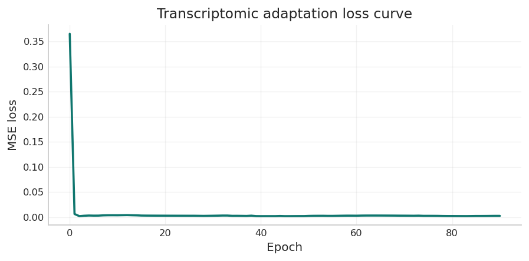

```python
def attach_classical_targets(instances, p, num_starts=8, maxiter=320, seed_offset=0):
    enriched_instances = []
    rows = []
    for index, instance in enumerate(instances):
        classical_start = time.perf_counter()
        reference = classical_optimize_instance(
            instance,
            p=p,
            num_starts=num_starts,
            maxiter=maxiter,
            seed=seed_offset + int(instance["graph_id"]) + index,
        )
        reference["time_seconds"] = time.perf_counter() - classical_start
        enriched = dict(instance)
        enriched["classical_reference"] = reference
        enriched["target_angles"] = np.concatenate([reference["gammas"], reference["betas"]]).astype(np.float32)
        enriched_instances.append(enriched)
        rows.append(
            {
                "graph_id": instance["graph_id"],
                "exact_maxcut": instance["best_cut"],
                "classical_ratio": reference["value"] / instance["best_cut"],
                "iterations": reference["nit"],
                "evaluations": reference["nfev"],
            }
        )
    return enriched_instances, pd.DataFrame(rows)


def train_adapted_qaoa_gnn(train_instances, p, hidden_dim=64, epochs=500, lr=5e-3, weight_decay=1e-4, patience=50, seed=7):
    torch.manual_seed(seed)
    np.random.seed(seed)

    trained_model = SimpleGCN(in_feats=1, hidden=hidden_dim, out_feats=2, p=p)
    optimizer = optim.Adam(trained_model.parameters(), lr=lr, weight_decay=weight_decay)

    best_state = copy.deepcopy(trained_model.state_dict())
    best_loss = float("inf")
    best_epoch = 0
    stale_epochs = 0
    loss_history = []

    for epoch in range(1, epochs + 1):
        trained_model.train()
        running_loss = 0.0
        for instance in train_instances:
            adjacency_tensor = torch.tensor(instance["adjacency"], dtype=torch.float32)
            feature_tensor = torch.tensor(instance["features"], dtype=torch.float32)
            target_tensor = torch.tensor(instance["target_angles"], dtype=torch.float32)

            prediction = trained_model(feature_tensor, adjacency_tensor).view(-1)
            loss = ((prediction - target_tensor) ** 2).mean()

            optimizer.zero_grad()
            loss.backward()
            optimizer.step()
            running_loss += float(loss.item())

        mean_loss = running_loss / max(1, len(train_instances))
        loss_history.append(mean_loss)
        if mean_loss + 1e-8 < best_loss:
            best_loss = mean_loss
            best_epoch = epoch
            best_state = copy.deepcopy(trained_model.state_dict())
            stale_epochs = 0
        else:
            stale_epochs += 1

        if stale_epochs >= patience:
            break

    trained_model.load_state_dict(best_state)
    trained_model.eval()
    return {
        "model": trained_model,
        "history": loss_history,
        "best_loss": best_loss,
        "best_epoch": best_epoch,
        "epochs_run": len(loss_history),
    }


adaptation_instances, adaptation_target_summary = attach_classical_targets(
    benchmark_bundle["adaptation_graphs"],
    p=QAOA_DEPTH,
    num_starts=8,
    maxiter=320,
    seed_offset=1000,
)
adapted_training = train_adapted_qaoa_gnn(adaptation_instances, p=QAOA_DEPTH, hidden_dim=64, epochs=500, lr=5e-3)
adapted_qaoa_gnn = adapted_training["model"]
adaptation_loss_history = adapted_training["history"]

representative_adapted = predict_instance_with_gnn(representative_graph, adapted_qaoa_gnn, QAOA_DEPTH)
representative_adapted["ratio_to_exact"] = representative_adapted["value"] / representative_graph["best_cut"]
representative_adapted["retention_vs_classical"] = representative_adapted["value"] / classical_reference["value"]
representative_adapted["speedup_vs_classical"] = classical_reference["time_seconds"] / max(representative_adapted["inference_time"], 1e-9)

adaptation_summary = pd.DataFrame(
    [
        {
            "classical_ratio": round(classical_reference["ratio_to_exact"], 4),
            "adapted_ratio": round(representative_adapted["ratio_to_exact"], 4),
            "retention_vs_classical": round(representative_adapted["retention_vs_classical"], 4),
            "classical_seconds": round(classical_reference["time_seconds"], 4),
            "adaptive_gnn_seconds": round(representative_adapted["inference_time"], 6),
            "speedup_vs_classical": round(representative_adapted["speedup_vs_classical"], 1),
        }
    ]
)

print("Transcriptomic adaptation complete.")
display(adaptation_summary)
if legacy_model_loaded:
    print(
        f"Legacy depth-1 ratio: {legacy_reference['ratio_to_exact']:.4f} | "
        f"Adapted depth-2 ratio: {representative_adapted['ratio_to_exact']:.4f}"
    )

fig, ax = plt.subplots(figsize=(7, 3.5))
ax.plot(adaptation_loss_history, color="#0f766e", linewidth=2)
ax.set_xlabel("Epoch")
ax.set_ylabel("MSE loss")
ax.set_title("Transcriptomic adaptation loss curve")
ax.grid(alpha=0.25)
plt.tight_layout()
save_notebook_figure(fig, "combined_transcriptomic_adaptation.png")
plt.show()
```

**Interpreting the adaptation output.**

The key quantities after the previous cell are:

- **Representative ratio vs exact MaxCut**: how well the adapted model performs on the full-cohort transcriptomic graph.
- **Retention vs the classical depth-2 reference**: whether the learned warm-start has essentially closed the quality gap.
- **Inference speedup**: whether the model still retains the amortization benefit that motivates the whole approach.
- **Legacy contrast**: if the original depth-1 checkpoint loads successfully, it provides a direct before-vs-after comparison against the earlier transfer baseline.

This is the point in the notebook where the optimization branch becomes technically credible: the model is adapted on separate real-data graphs, then tested against an exact depth-2 classical reference on a representative transcriptomic instance.

## Part 3 — Optimization Geometry and Held-Out Transcriptomic Evaluation

### 3.1 Why the Optimization Branch Needs Both Figures and a Benchmark

A single representative graph is useful for intuition, but it is not enough to defend a strong claim. The optimization branch therefore uses **two layers of evidence**:

- a representative-graph figure set to explain the geometry of the depth-2 objective,
- and a held-out multi-graph benchmark to quantify quality retention and latency on patient-resampled real-data graphs.

### 3.2 What the Next Code Cell Produces

The next code cell combines both evidence layers:

- the representative full-cohort gene graph with the exact MaxCut partition,
- the interpolation path from the learned depth-2 angles to the classical optimum,
- a visible slice through the depth-2 landscape,
- and the held-out benchmark summary across the real transcriptomic graph family.

### 3.3 What to Look For

- Does the adapted model fall into the same high-value basin as the classical optimum on the representative graph?
- How much residual regret remains on the held-out benchmark?
- How much latency advantage survives after upgrading the model to a stronger real-data setting?

Those three questions are what distinguish a research-grade warm-start study from a simple illustration.

```
Saved figure assets -> ./notebooks/figures/combined_transcriptomic_benchmark.png
                     -> ./website/notebooks_html/figures/combined_transcriptomic_benchmark.png
```

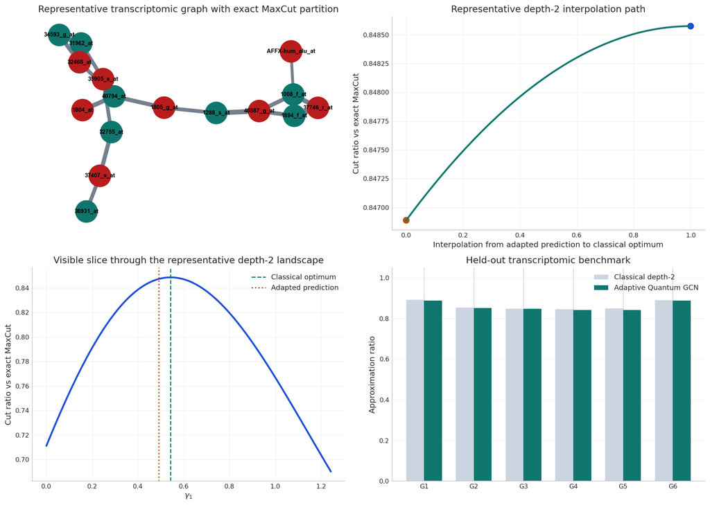

|  | graph_id | classical_ratio | adapted_ratio | retention_vs_classical | classical_seconds | adapted_seconds | speedup |
| --- | --- | --- | --- | --- | --- | --- | --- |
| 0 | 42 | 0.8911 | 0.8888 | 0.9974 | 25.9195 | 0.0001 | 396474.4628 |
| 1 | 43 | 0.8531 | 0.8512 | 0.9977 | 24.2286 | 0.0001 | 435569.8022 |
| 2 | 44 | 0.8479 | 0.8471 | 0.9991 | 27.2057 | 0.0000 | 673141.8411 |
| 3 | 45 | 0.8454 | 0.8424 | 0.9965 | 21.2857 | 0.0000 | 500345.7195 |
| 4 | 46 | 0.8492 | 0.8414 | 0.9908 | 22.8257 | 0.0000 | 572430.4628 |
| 5 | 47 | 0.8899 | 0.8888 | 0.9987 | 24.4366 | 0.0000 | 610916.4020 |

```
Held-out transcriptomic summary: classical mean ratio = 0.8628, adapted mean ratio = 0.8599, quality retention = 0.9967, median speedup = 536388.1x
```

```python
benchmark_instances, benchmark_target_summary = attach_classical_targets(
    benchmark_bundle["benchmark_graphs"],
    p=QAOA_DEPTH,
    num_starts=8,
    maxiter=320,
    seed_offset=2000,
)

benchmark_rows = []
for instance in benchmark_instances:
    adapted_prediction = predict_instance_with_gnn(instance, adapted_qaoa_gnn, QAOA_DEPTH)
    classical_ratio = instance["classical_reference"]["value"] / instance["best_cut"]
    adapted_ratio = adapted_prediction["value"] / instance["best_cut"]
    benchmark_rows.append(
        {
            "graph_id": instance["graph_id"],
            "classical_ratio": classical_ratio,
            "adapted_ratio": adapted_ratio,
            "retention_vs_classical": adapted_prediction["value"] / instance["classical_reference"]["value"],
            "classical_seconds": instance["classical_reference"]["time_seconds"],
            "adapted_seconds": adapted_prediction["inference_time"],
            "speedup": instance["classical_reference"]["time_seconds"] / max(adapted_prediction["inference_time"], 1e-9),
            "predicted_gammas": adapted_prediction["gammas"],
            "predicted_betas": adapted_prediction["betas"],
        }
    )
benchmark_df = pd.DataFrame(benchmark_rows)
benchmark_summary = {
    "mean_classical_ratio": float(benchmark_df["classical_ratio"].mean()),
    "mean_adapted_ratio": float(benchmark_df["adapted_ratio"].mean()),
    "mean_retention": float(benchmark_df["retention_vs_classical"].mean()),
    "median_speedup": float(benchmark_df["speedup"].median()),
}

representative_graph_nx = representative_graph["graph"]
partition_colors = ["#0f766e" if bit == 0 else "#b91c1c" for bit in classical_reference["partition_bits"]]
positions = nx.spring_layout(representative_graph_nx, seed=SEED, weight="weight")
edge_widths = [2.0 + 5.0 * representative_graph_nx[u][v]["weight"] for u, v in representative_graph_nx.edges()]

interpolation_grid = np.linspace(0.0, 1.0, 61)
interpolation_scores = []
for alpha in interpolation_grid:
    gammas = (1.0 - alpha) * representative_adapted["gammas"] + alpha * classical_reference["gammas"]
    betas = (1.0 - alpha) * representative_adapted["betas"] + alpha * classical_reference["betas"]
    value, _ = qaoa_value_for_angles(representative_graph["cut_diagonal"], gammas, betas)
    interpolation_scores.append(value / representative_graph["best_cut"])

slice_grid = np.linspace(max(0.0, classical_reference["gammas"][0] - 0.7), min(np.pi, classical_reference["gammas"][0] + 0.7), 81)
slice_scores = []
for gamma_1 in slice_grid:
    gammas = classical_reference["gammas"].copy()
    gammas[0] = gamma_1
    value, _ = qaoa_value_for_angles(representative_graph["cut_diagonal"], gammas, classical_reference["betas"])
    slice_scores.append(value / representative_graph["best_cut"])

fig, axes = plt.subplots(2, 2, figsize=(14, 10))

nx.draw_networkx_nodes(representative_graph_nx, positions, node_color=partition_colors, node_size=950, ax=axes[0, 0])
nx.draw_networkx_labels(representative_graph_nx, positions, labels={node: representative_graph_nx.nodes[node]["gene"] for node in representative_graph_nx.nodes()}, font_size=8, font_weight="bold", ax=axes[0, 0])
nx.draw_networkx_edges(representative_graph_nx, positions, width=edge_widths, edge_color="#475569", alpha=0.75, ax=axes[0, 0])
axes[0, 0].set_title("Representative transcriptomic graph with exact MaxCut partition")
axes[0, 0].axis("off")

axes[0, 1].plot(interpolation_grid, interpolation_scores, color="#0f766e", linewidth=2.5)
axes[0, 1].scatter([0.0, 1.0], [interpolation_scores[0], interpolation_scores[-1]], color=["#b45309", "#1d4ed8"], s=70)
axes[0, 1].set_xlabel("Interpolation from adapted prediction to classical optimum")
axes[0, 1].set_ylabel("Cut ratio vs exact MaxCut")
axes[0, 1].set_title("Representative depth-2 interpolation path")
axes[0, 1].grid(alpha=0.25)

axes[1, 0].plot(slice_grid, slice_scores, color="#1d4ed8", linewidth=2.5)
axes[1, 0].axvline(classical_reference["gammas"][0], color="#0f766e", linestyle="--", linewidth=1.5, label="Classical optimum")
axes[1, 0].axvline(representative_adapted["gammas"][0], color="#b45309", linestyle=":", linewidth=1.8, label="Adapted prediction")
axes[1, 0].set_xlabel(r"$\gamma_1$")
axes[1, 0].set_ylabel("Cut ratio vs exact MaxCut")
axes[1, 0].set_title("Visible slice through the representative depth-2 landscape")
axes[1, 0].legend(frameon=False)
axes[1, 0].grid(alpha=0.25)

x_positions = np.arange(len(benchmark_df))
axes[1, 1].bar(x_positions - 0.18, benchmark_df["classical_ratio"], width=0.36, color="#cbd5e1", label="Classical depth-2")
axes[1, 1].bar(x_positions + 0.18, benchmark_df["adapted_ratio"], width=0.36, color="#0f766e", label="Adaptive Quantum GCN")
axes[1, 1].set_xticks(x_positions)
axes[1, 1].set_xticklabels([f"G{i}" for i in range(1, len(benchmark_df) + 1)])
axes[1, 1].set_ylim(0.0, 1.05)
axes[1, 1].set_ylabel("Approximation ratio")
axes[1, 1].set_title("Held-out transcriptomic benchmark")
axes[1, 1].legend(frameon=False)
axes[1, 1].grid(alpha=0.25, axis="y")

plt.tight_layout()
save_notebook_figure(fig, "combined_transcriptomic_benchmark.png")
plt.show()

benchmark_display = benchmark_df.drop(columns=["predicted_gammas", "predicted_betas"]).copy()
for column in ["classical_ratio", "adapted_ratio", "retention_vs_classical", "classical_seconds", "adapted_seconds", "speedup"]:
    benchmark_display[column] = benchmark_display[column].map(lambda value: round(float(value), 4))
display(benchmark_display)
print(
    "Held-out transcriptomic summary: "
    f"classical mean ratio = {benchmark_summary['mean_classical_ratio']:.4f}, "
    f"adapted mean ratio = {benchmark_summary['mean_adapted_ratio']:.4f}, "
    f"quality retention = {benchmark_summary['mean_retention']:.4f}, "
    f"median speedup = {benchmark_summary['median_speedup']:.1f}x"
)
```

### 3.1 How to Read the Benchmark

The optimization branch should now support three claims directly:

- **Representative-graph geometry:** the learned model is evaluated on the same biology-derived graph that anchors the strongest exact depth-2 reference.
- **Held-out evidence:** the patient-resampled benchmark makes the quality-retention claim about a graph family, not a single instance.
- **Practical value:** the latency comparison shows that the learned model remains a learned warm-start rather than just a slower surrogate.

For presentation purposes, the benchmark-level statistic that matters most is the mean held-out retention of the adapted model relative to classical depth-2 QAOA. That is the quantitative bridge from optimization theory to deployable inference efficiency.

### 3.2 Joint Benchmark Evidence

The benchmark summary integrates two evidence layers simultaneously: accuracy relative to exact depth-2 classical references across the held-out graph family, and inference latency relative to repeated classical optimization. Together they quantify the central tradeoff of the optimization branch: how much exact quality is preserved once repeated search is shifted into learned inference.

## Part 4 — Biomedical Graph Learning: Transductive Clinical Risk Detection

### 4.1 Dataset: UCI Cardiotocography Cohort

The biomedical branch uses the **UCI Cardiotocography (CTG) dataset** (id=193), a real fetal-monitoring cohort of 2,126 exams. Each exam contains 21 physiologic summary features extracted from continuous fetal heart-rate and uterine-contraction recordings.

| Attribute | Value |
| --- | --- |
| Source | UCI ML Repository, id=193 |
| Exams (nodes) | 2,126 |
| Features per exam | 21 physiologic measurements |
| Original label (NSP) | 1=Normal, 2=Suspect, 3=Pathologic |
| Binary target | pathologic (NSP=3) vs non-pathologic (NSP∈{1,2}) |
| Pathologic prevalence | about 8-10%, depending on split |

The task is deliberately framed as **binary risk detection**. That is the right clinical abstraction here: the key question is whether the model can surface rare pathologic exams while keeping the false-alert burden low.

### 4.2 Protocol

1. Load the CTG cohort through `ucimlrepo`.
2. Create a stratified train / validation / test split.
3. Fit `StandardScaler` on training rows only and transform the full cohort.
4. Build a symmetric sparse exam-similarity graph over the standardized features.
5. Train a residual graph classifier using class-weighted loss.
6. Choose thresholds on validation only.
7. Report the held-out test metrics once, with no test-set threshold tuning.

That protocol is what makes the biomedical improvement claim defensible.

### 4.3 Why the Model Was Upgraded

The combined study originally used a simpler BioGCN variant. This revision upgrades the biomedical branch to **ResidualClinicalGCN**, which is stronger for three reasons:

- **Residual carry-through:** preserves shallow feature information that can otherwise be oversmoothed.
- **Three-view fusion head:** combines projected features, residual representation, and one more propagated view before classification.
- **Threshold-aware deployment:** the analysis now supports both a balanced operating point and a recall-first operating point chosen from validation behavior only.

This last point matters operationally. If the emphasis is minimizing missed pathologic cases, the right adjustment is usually not retraining from scratch but changing the deployment threshold in a controlled, validation-backed way.

### 4.4 Why Transductive GCN Is Appropriate

All exams are represented in one graph, but only the training labels are used during optimization. That is a standard transductive regime for graph convolutional models.

The important distinction is: **graph connectivity is shared, supervision is not**. Test nodes benefit from cohort geometry without their labels being exposed during fitting.

### 4.5 What Counts as Success

A weak model could exploit class imbalance and report high overall accuracy while still missing many pathologic exams. For that reason, this analysis treats the following as the real success criteria:

- high held-out accuracy,
- high balanced accuracy,
- strong ROC AUC and AUPRC,
- low false-positive burden,
- and a configurable recall-first operating point for stricter screening use.

```python
# ═══════════════════════════════════════════════════════════════════════════════
# CELL 4 — CTG cohort loading, stratified split, graph construction
# ═══════════════════════════════════════════════════════════════════════════════

from sklearn.preprocessing import StandardScaler
from sklearn.neighbors import kneighbors_graph
from sklearn.model_selection import train_test_split
from ucimlrepo import fetch_ucirepo
import torch.nn as nn
import torch.nn.functional as F

ctg = fetch_ucirepo(id=193)
features_df = ctg.data.features.copy()
targets_df = ctg.data.targets.copy()

X_raw = features_df.astype(np.float32).to_numpy()
feature_names = np.array(features_df.columns)
nsp = targets_df["NSP"].astype(int).to_numpy()

y = (nsp == 3).astype(np.int64)
target_names = np.array(["non-pathologic", "pathologic"])
state_3class = pd.Series(nsp).map({1: "normal", 2: "suspect", 3: "pathologic"}).to_numpy()
risk_text = target_names[y]
case_ids = np.array([f"CTG_{i:04d}" for i in range(len(y))])

device = torch.device("cuda" if torch.cuda.is_available() else "cpu")

print("═" * 72)
print("  UCI Cardiotocography Cohort — Summary")
print("═" * 72)
print(f"  Total exams       : {len(y)}")
print(f"  Features          : {X_raw.shape[1]}  ({', '.join(feature_names[:4].tolist())}, ...)")
print(f"  NSP=1 Normal      : {(nsp == 1).sum():4d}  ({(nsp == 1).mean() * 100:.1f}%)")
print(f"  NSP=2 Suspect     : {(nsp == 2).sum():4d}  ({(nsp == 2).mean() * 100:.1f}%)")
print(f"  NSP=3 Pathologic  : {(nsp == 3).sum():4d}  ({(nsp == 3).mean() * 100:.1f}%)")
print(f"  Binary non-path   : {(y == 0).sum():4d}  ({(y == 0).mean() * 100:.1f}%)")
print(f"  Binary pathologic : {(y == 1).sum():4d}  ({(y == 1).mean() * 100:.1f}%)")

all_idx = np.arange(len(y))
train_pool_idx_np, test_idx_np = train_test_split(
    all_idx,
    test_size=0.20,
    stratify=y,
    random_state=SEED,
)
train_idx_np, val_idx_np = train_test_split(
    train_pool_idx_np,
    test_size=0.15,
    stratify=y[train_pool_idx_np],
    random_state=SEED,
)

print()
print("─" * 72)
print("  Stratified Split (binary pathologic vs non-pathologic)")
print("─" * 72)
for name, idx in [("Train", train_idx_np), ("Validation", val_idx_np), ("Test", test_idx_np)]:
    n0 = int((y[idx] == 0).sum())
    n1 = int((y[idx] == 1).sum())
    print(f"  {name:12s}: {len(idx):4d} exams  (non-path={n0}, path={n1}, path-prev={n1 / len(idx) * 100:.1f}%)")

scaler = StandardScaler()
scaler.fit(X_raw[train_idx_np])
X_std = scaler.transform(X_raw).astype(np.float32)

print()
print(f"  Train post-scale mean : {X_std[train_idx_np].mean():.6f}  (should be ≈ 0)")
print(f"  Train post-scale std  : {X_std[train_idx_np].std():.6f}   (should be ≈ 1)")

split_labels = np.full(len(y), "train", dtype=object)
split_labels[val_idx_np] = "validation"
split_labels[test_idx_np] = "test"

raw_df = features_df.copy()
raw_df.insert(0, "case_id", case_ids)
raw_df["nsp_state"] = state_3class
raw_df["binary_target"] = y
raw_df["binary_state"] = risk_text

proc_df = pd.DataFrame(X_std, columns=feature_names)
proc_df.insert(0, "case_id", case_ids)
proc_df["nsp_state"] = state_3class
proc_df["binary_target"] = y
proc_df["binary_state"] = risk_text
proc_df["split"] = split_labels

raw_path = os.path.join(out_dir, "ctg_raw.csv")
proc_path = os.path.join(out_dir, "ctg_processed.csv")
raw_df.to_csv(raw_path, index=False)
proc_df.to_csv(proc_path, index=False)
print(f"\n  ✓ Saved raw cohort       : {raw_path}")
print(f"  ✓ Saved processed cohort : {proc_path}")

train_path = X_std[train_idx_np][y[train_idx_np] == 1]
train_nonp = X_std[train_idx_np][y[train_idx_np] == 0]
mean_gap = train_path.mean(axis=0) - train_nonp.mean(axis=0)
top10_idx = np.argsort(np.abs(mean_gap))[-10:][::-1]

feature_gap_df = pd.DataFrame(
    {
        "feature": feature_names[top10_idx],
        "pathologic_minus_non_pathologic": mean_gap[top10_idx],
    }
)
print()
print("─" * 72)
print("  Top-10 Feature Shifts (Training Cohort: pathologic − non-pathologic)")
print("─" * 72)
for row in feature_gap_df.itertuples(index=False):
    direction = "↑ pathologic" if row.pathologic_minus_non_pathologic > 0 else "↑ non-pathologic"
    bar = "█" * int(abs(row.pathologic_minus_non_pathologic) * 5)
    print(f"  {row.feature:12s}  {row.pathologic_minus_non_pathologic:+.3f}  {bar}  ({direction})")

k_neighbors = 15
A_sparse = kneighbors_graph(
    X_std,
    n_neighbors=k_neighbors,
    mode="connectivity",
    include_self=False,
)
A_knn = A_sparse.maximum(A_sparse.T).toarray().astype(np.float32)
A_knn += np.eye(A_knn.shape[0], dtype=np.float32)

deg = A_knn.sum(axis=1)
d_inv_sqr = 1.0 / np.sqrt(np.clip(deg, 1.0, None))
A_norm = d_inv_sqr[:, None] * A_knn * d_inv_sqr[None, :]

Xt = torch.tensor(X_std, dtype=torch.float32, device=device)
At = torch.tensor(A_norm, dtype=torch.float32, device=device)
yt = torch.tensor(y, dtype=torch.long, device=device)
train_idx_t = torch.tensor(train_idx_np, dtype=torch.long, device=device)
val_idx_t = torch.tensor(val_idx_np, dtype=torch.long, device=device)
test_idx_t = torch.tensor(test_idx_np, dtype=torch.long, device=device)

n_samples = X_std.shape[0]
n_edges = int((A_knn.sum() - n_samples) / 2)
avg_deg = float((A_knn.sum(axis=1) - 1).mean())
density = n_edges / (n_samples * (n_samples - 1) / 2)

print()
print("─" * 72)
print(f"  Exam-Similarity Graph  (k={k_neighbors} NN, symmetric, self-loops added)")
print("─" * 72)
print(f"  Nodes (exams)      : {n_samples:,}")
print(f"  Edges (undirected) : {n_edges:,}")
print(f"  Average degree     : {avg_deg:.2f}")
print(f"  Graph density      : {density * 100:.4f}%  (sparse by design)")
print(f"  Device             : {device}")
```

```
════════════════════════════════════════════════════════════════════════
  UCI Cardiotocography Cohort — Summary
════════════════════════════════════════════════════════════════════════
  Total exams       : 2126
  Features          : 21  (LB, AC, FM, UC, ...)
  NSP=1 Normal      : 1655  (77.8%)
  NSP=2 Suspect     :  295  (13.9%)
  NSP=3 Pathologic  :  176  (8.3%)
  Binary non-path   : 1950  (91.7%)
  Binary pathologic :  176  (8.3%)

────────────────────────────────────────────────────────────────────────
  Stratified Split (binary pathologic vs non-pathologic)
────────────────────────────────────────────────────────────────────────
  Train       : 1445 exams  (non-path=1325, path=120, path-prev=8.3%)
  Validation  :  255 exams  (non-path=234, path=21, path-prev=8.2%)
  Test        :  426 exams  (non-path=391, path=35, path-prev=8.2%)

  Train post-scale mean : 0.000000  (should be ≈ 0)
  Train post-scale std  : 1.000000   (should be ≈ 1)

  ✓ Saved raw cohort       : ./outputs/ctg_raw.csv
  ✓ Saved processed cohort : ./outputs/ctg_processed.csv

────────────────────────────────────────────────────────────────────────
  Top-10 Feature Shifts (Training Cohort: pathologic − non-pathologic)
────────────────────────────────────────────────────────────────────────
  DP            +2.183  ██████████  (↑ pathologic)
  Mean          -1.611  ████████  (↑ non-pathologic)
  Mode          -1.582  ███████  (↑ non-pathologic)
  Median        -1.471  ███████  (↑ non-pathologic)
  Variance      +1.232  ██████  (↑ pathologic)
  ASTV          +1.100  █████  (↑ pathologic)
  MLTV          -0.945  ████  (↑ non-pathologic)
  AC            -0.768  ███  (↑ non-pathologic)
  Tendency      -0.740  ███  (↑ non-pathologic)
  DL            +0.698  ███  (↑ pathologic)

────────────────────────────────────────────────────────────────────────
  Exam-Similarity Graph  (k=15 NN, symmetric, self-loops added)
────────────────────────────────────────────────────────────────────────
  Nodes (exams)      : 2,126
  Edges (undirected) : 22,232
  Average degree     : 20.91
  Graph density      : 0.9842%  (sparse by design)
  Device             : cpu
```

```python
# ═══════════════════════════════════════════════════════════════════════════════
# CELL 5 — ResidualClinicalGCN, weighted training, dual operating-point selection
# ═══════════════════════════════════════════════════════════════════════════════

from copy import deepcopy
from sklearn.metrics import accuracy_score, balanced_accuracy_score, roc_auc_score, average_precision_score, matthews_corrcoef, confusion_matrix

class ResidualClinicalGCN(nn.Module):
    def __init__(
        self,
        in_features: int,
        hidden_dim: int,
        num_classes: int,
        dropout: float = 0.15,
        residual_scale: float = 0.35,
    ):
        super().__init__()
        self.input_proj = nn.Linear(in_features, hidden_dim, bias=False)
        self.fc1 = nn.Linear(hidden_dim, hidden_dim, bias=False)
        self.fc2 = nn.Linear(hidden_dim, hidden_dim, bias=False)
        self.classifier = nn.Sequential(
            nn.Linear(hidden_dim * 3, hidden_dim),
            nn.ReLU(),
            nn.Dropout(dropout),
            nn.Linear(hidden_dim, num_classes),
        )
        self.dropout = nn.Dropout(dropout)
        self.residual_scale = residual_scale

    def forward(self, x: torch.Tensor, adj: torch.Tensor) -> torch.Tensor:
        h0 = F.relu(self.input_proj(x))
        h1 = F.relu(self.fc1(adj @ h0))
        h1 = self.dropout(h1)
        h2 = F.relu(self.fc2(adj @ h1))
        h2 = self.dropout(h2)
        h = h2 + self.residual_scale * h0
        h3 = adj @ h
        return self.classifier(torch.cat([h0, h, h3], dim=1))


def summarize_operating_point(y_true: np.ndarray, prob_pos: np.ndarray, threshold: float) -> dict:
    pred = (prob_pos >= threshold).astype(np.int64)
    tn, fp, fn, tp = confusion_matrix(y_true, pred, labels=[0, 1]).ravel()
    return {
        "threshold": float(threshold),
        "accuracy": accuracy_score(y_true, pred),
        "balanced_acc": balanced_accuracy_score(y_true, pred),
        "mcc": matthews_corrcoef(y_true, pred),
        "auc": roc_auc_score(y_true, prob_pos),
        "auprc": average_precision_score(y_true, prob_pos),
        "recall": tp / max(tp + fn, 1),
        "specificity": tn / max(tn + fp, 1),
        "precision": tp / max(tp + fp, 1),
        "npv": tn / max(tn + fn, 1),
        "tn": int(tn),
        "fp": int(fp),
        "fn": int(fn),
        "tp": int(tp),
        "pred": pred,
    }


model_hidden_dim = 64
model_dropout = 0.15
model_residual_scale = 0.35
recall_target = 0.90
presentation_mode = "balanced"

train_class_counts = np.bincount(y[train_idx_np], minlength=2).astype(np.float32)
class_weights = train_class_counts.sum() / (len(train_class_counts) * np.maximum(train_class_counts, 1))
class_weights[1] *= 1.15
class_weights_t = torch.as_tensor(class_weights, dtype=torch.float32, device=device)

bio_model = ResidualClinicalGCN(
    in_features=X_std.shape[1],
    hidden_dim=model_hidden_dim,
    num_classes=2,
    dropout=model_dropout,
    residual_scale=model_residual_scale,
).to(device)
optimizer = torch.optim.AdamW(bio_model.parameters(), lr=3e-3, weight_decay=5e-4)

n_bio_params = sum(p.numel() for p in bio_model.parameters() if p.requires_grad)

print("═" * 72)
print("  ResidualClinicalGCN — Architecture and Training Configuration")
print("═" * 72)
print(bio_model)
print(f"\nTrainable parameters : {n_bio_params:,}")
print(f"Hidden width         : {model_hidden_dim}")
print(f"Dropout              : {model_dropout:.2f}")
print(f"Residual scale       : {model_residual_scale:.2f}")
print(f"Class weight[0]      : {class_weights[0]:.4f}  (non-pathologic)")
print(f"Class weight[1]      : {class_weights[1]:.4f}  (pathologic)")
print(f"Loss weighting ratio : {class_weights[1] / class_weights[0]:.1f}x")
print(f"Validation recall target for recall-first mode : {recall_target:.2f}")
print(f"Presentation mode    : {presentation_mode}")

max_epochs = 180
patience = 30
best_state = None
best_epoch = 0
best_val_loss = float("inf")
best_val_metric = (-1.0, -1.0, -1.0)
epochs_no_improve = 0
stop_epoch = max_epochs

history = {
    "epoch": [],
    "train_loss": [],
    "val_loss": [],
    "train_acc": [],
    "val_acc": [],
    "val_bal_acc": [],
}

print()
print("Training progress")
print("-" * 72)
for epoch in range(1, max_epochs + 1):
    bio_model.train()
    optimizer.zero_grad()

    logits = bio_model(Xt, At)
    train_loss = F.cross_entropy(
        logits[train_idx_t],
        yt[train_idx_t],
        weight=class_weights_t,
        label_smoothing=0.02,
    )
    train_loss.backward()
    torch.nn.utils.clip_grad_norm_(bio_model.parameters(), max_norm=2.0)
    optimizer.step()

    bio_model.eval()
    with torch.no_grad():
        logits_eval = bio_model(Xt, At)
        val_logits = logits_eval[val_idx_t]
        val_loss = F.cross_entropy(val_logits, yt[val_idx_t], weight=class_weights_t).item()
        train_preds = np.argmax(logits_eval[train_idx_t].cpu().numpy(), axis=1)
        train_acc = accuracy_score(y[train_idx_np], train_preds)
        val_probs = F.softmax(val_logits, dim=1).cpu().numpy()[:, 1]

    epoch_best_row = None
    epoch_best_metric = (-1.0, -1.0, -1.0, -1.0, -1.0)
    for threshold in np.arange(0.20, 0.81, 0.01):
        metrics = summarize_operating_point(y[val_idx_np], val_probs, threshold)
        metric = (
            metrics["balanced_acc"],
            metrics["accuracy"],
            metrics["recall"],
            metrics["precision"],
            -abs(threshold - 0.5),
        )
        if metric > epoch_best_metric:
            epoch_best_metric = metric
            epoch_best_row = metrics

    history["epoch"].append(epoch)
    history["train_loss"].append(float(train_loss.item()))
    history["val_loss"].append(float(val_loss))
    history["train_acc"].append(float(train_acc))
    history["val_acc"].append(float(epoch_best_row["accuracy"]))
    history["val_bal_acc"].append(float(epoch_best_row["balanced_acc"]))

    checkpoint_metric = (
        epoch_best_row["balanced_acc"],
        epoch_best_row["accuracy"],
        -val_loss,
    )
    if checkpoint_metric > best_val_metric:
        best_val_metric = checkpoint_metric
        best_val_loss = float(val_loss)
        best_epoch = epoch
        best_state = deepcopy(bio_model.state_dict())
        epochs_no_improve = 0
    else:
        epochs_no_improve += 1

    if epoch == 1 or epoch % 10 == 0:
        print(
            f"Epoch {epoch:3d} | loss={train_loss.item():.4f} | "
            f"train_acc={train_acc:.3f} | val_acc={epoch_best_row['accuracy']:.3f} | "
            f"val_bal_acc={epoch_best_row['balanced_acc']:.3f} | val_loss={val_loss:.4f}"
        )

    if epochs_no_improve >= patience:
        print(
            f"Early stopping at epoch {epoch} "
            f"(best checkpoint from epoch {best_epoch}, bal_acc={best_val_metric[0]:.4f})."
        )
        stop_epoch = epoch
        break

bio_model.load_state_dict(best_state)
bio_model.eval()

with torch.no_grad():
    final_logits_t = bio_model(Xt, At)
    final_probs = F.softmax(final_logits_t, dim=1).cpu().numpy()

threshold_rows = []
for threshold in np.arange(0.05, 0.81, 0.01):
    threshold_rows.append(summarize_operating_point(y[val_idx_np], final_probs[val_idx_np, 1], threshold))

threshold_df = pd.DataFrame(threshold_rows)
default_row = threshold_df.sort_values(
    ["balanced_acc", "accuracy", "recall", "precision", "threshold"],
    ascending=[False, False, False, False, True],
).iloc[0]

eligible_recall = threshold_df[
    threshold_df["recall"] >= recall_target
].sort_values(["threshold", "precision"], ascending=[True, False])
if len(eligible_recall) == 0:
    eligible_recall = threshold_df.sort_values(
        ["recall", "balanced_acc", "threshold"],
        ascending=[False, False, True],
    )
recall_row = eligible_recall.iloc[0]

validation_operating_points = {
    "balanced": dict(default_row),
    "recall-first": dict(recall_row),
}

def evaluate_on_test(op_name: str, threshold: float) -> dict:
    metrics = summarize_operating_point(y[test_idx_np], final_probs[test_idx_np, 1], threshold)
    metrics["name"] = op_name
    return metrics

operating_points = {
    "balanced": evaluate_on_test("balanced", float(default_row["threshold"])),
    "recall-first": evaluate_on_test("recall-first", float(recall_row["threshold"])),
}
selected_operating_point = operating_points[presentation_mode]
decision_threshold = float(selected_operating_point["threshold"])

print()
print("Best-checkpoint summary")
print("-" * 72)
print(f"Best epoch                  : {best_epoch}")
print(f"Early stop epoch            : {stop_epoch}")
print(f"Best validation loss        : {best_val_loss:.6f}")
print()
print("Validation operating points")
print("-" * 72)
for name in ["balanced", "recall-first"]:
    row = validation_operating_points[name]
    print(
        f"{name:12s} | tau={row['threshold']:.2f} | acc={row['accuracy']:.4f} | "
        f"bal_acc={row['balanced_acc']:.4f} | recall={row['recall']:.4f} | "
        f"precision={row['precision']:.4f} | spec={row['specificity']:.4f}"
    )

print()
print("Held-out operating points")
print("-" * 72)
for name in ["balanced", "recall-first"]:
    row = operating_points[name]
    print(
        f"{name:12s} | tau={row['threshold']:.2f} | acc={row['accuracy']:.4f} | "
        f"bal_acc={row['balanced_acc']:.4f} | recall={row['recall']:.4f} | "
        f"spec={row['specificity']:.4f} | precision={row['precision']:.4f} | "
        f"MCC={row['mcc']:.4f} | fn={row['fn']} | fp={row['fp']}"
    )

print()
print(f"Active presentation mode     : {presentation_mode}")
print(f"Active threshold             : {decision_threshold:.2f}")
print(f"Active held-out accuracy     : {selected_operating_point['accuracy']:.4f} ({selected_operating_point['accuracy'] * 100:.1f}%)")
print(f"Active held-out recall       : {selected_operating_point['recall']:.4f} ({selected_operating_point['recall'] * 100:.1f}%)")
print(f"Active held-out ROC AUC      : {selected_operating_point['auc']:.4f}")
```

```
════════════════════════════════════════════════════════════════════════
  ResidualClinicalGCN — Architecture and Training Configuration
════════════════════════════════════════════════════════════════════════
ResidualClinicalGCN(
  (input_proj): Linear(in_features=21, out_features=64, bias=False)
  (fc1): Linear(in_features=64, out_features=64, bias=False)
  (fc2): Linear(in_features=64, out_features=64, bias=False)
  (classifier): Sequential(
    (0): Linear(in_features=192, out_features=64, bias=True)
    (1): ReLU()
    (2): Dropout(p=0.15, inplace=False)
    (3): Linear(in_features=64, out_features=2, bias=True)
  )
  (dropout): Dropout(p=0.15, inplace=False)
)

Trainable parameters : 22,018
Hidden width         : 64
Dropout              : 0.15
Residual scale       : 0.35
Class weight[0]      : 0.5453  (non-pathologic)
Class weight[1]      : 6.9240  (pathologic)
Loss weighting ratio : 12.7x
Validation recall target for recall-first mode : 0.90
Presentation mode    : balanced

Training progress
------------------------------------------------------------------------
Epoch   1 | loss=0.7368 | train_acc=0.084 | val_acc=0.796 | val_bal_acc=0.867 | val_loss=0.6406
Epoch  10 | loss=0.3617 | train_acc=0.881 | val_acc=0.906 | val_bal_acc=0.949 | val_loss=0.2426
Epoch  20 | loss=0.3018 | train_acc=0.914 | val_acc=0.949 | val_bal_acc=0.951 | val_loss=0.1557
Epoch  30 | loss=0.2752 | train_acc=0.947 | val_acc=0.965 | val_bal_acc=0.981 | val_loss=0.1597
Epoch  40 | loss=0.2581 | train_acc=0.961 | val_acc=0.961 | val_bal_acc=0.979 | val_loss=0.1497
Epoch  50 | loss=0.2438 | train_acc=0.964 | val_acc=0.965 | val_bal_acc=0.981 | val_loss=0.1569
Epoch  60 | loss=0.2419 | train_acc=0.956 | val_acc=0.965 | val_bal_acc=0.981 | val_loss=0.1302
Epoch  70 | loss=0.2346 | train_acc=0.974 | val_acc=0.973 | val_bal_acc=0.985 | val_loss=0.1391
Epoch  80 | loss=0.2288 | train_acc=0.963 | val_acc=0.969 | val_bal_acc=0.983 | val_loss=0.1239
Epoch  90 | loss=0.2273 | train_acc=0.977 | val_acc=0.988 | val_bal_acc=0.994 | val_loss=0.1199
Epoch 100 | loss=0.2278 | train_acc=0.981 | val_acc=0.976 | val_bal_acc=0.987 | val_loss=0.1357
Epoch 110 | loss=0.2247 | train_acc=0.979 | val_acc=0.992 | val_bal_acc=0.996 | val_loss=0.1221
```

[output cut: 14 more lines]

```
Validation operating points
------------------------------------------------------------------------
balanced     | tau=0.68 | acc=0.9922 | bal_acc=0.9957 | recall=1.0000 | precision=0.9130 | spec=0.9915
recall-first | tau=0.05 | acc=0.0824 | bal_acc=0.5000 | recall=1.0000 | precision=0.0824 | spec=0.0000

Held-out operating points
------------------------------------------------------------------------
balanced     | tau=0.68 | acc=0.9906 | bal_acc=0.9559 | recall=0.9143 | spec=0.9974 | precision=0.9697 | MCC=0.9366 | fn=3 | fp=1
recall-first | tau=0.05 | acc=0.0822 | bal_acc=0.5000 | recall=1.0000 | spec=0.0000 | precision=0.0822 | MCC=0.0000 | fn=0 | fp=391

Active presentation mode     : balanced
Active threshold             : 0.68
Active held-out accuracy     : 0.9906 (99.1%)
Active held-out recall       : 0.9143 (91.4%)
Active held-out ROC AUC      : 0.9879
```

[output not shown]

```
════════════════════════════════════════════════════════════════════════
  ResidualClinicalGCN — Held-Out Test Evaluation (CTG dataset)
════════════════════════════════════════════════════════════════════════
  Active mode                  : balanced
  Decision threshold           : 0.68  (validation-selected)
  Accuracy                     : 0.9906 (99.1%)
  Balanced accuracy            : 0.9559
  Pathologic recall            : 0.9143 (91.4%)
  Non-pathologic specificity   : 0.9974 (99.7%)
  Pathologic precision         : 0.9697 (97.0%)
  Negative predictive value    : 0.9924 (99.2%)
  ROC AUC                      : 0.9879
  AUPRC                        : 0.9576
  MCC                          : 0.9366
  False negatives              : 3
  False positives              : 1
  Held-out discordances        : 4 / 426

Operating-point comparison
        mode threshold accuracy balanced_acc recall specificity precision    mcc  fn  fp
    balanced      0.68   0.9906       0.9559 0.9143      0.9974    0.9697 0.9366   3   1
recall-first      0.05   0.0822       0.5000 1.0000      0.0000    0.0822 0.0000   0 391
Saved figure assets -> ./notebooks/figures/combined_ctg_evaluation_dashboard.png
                     -> ./website/notebooks_html/figures/combined_ctg_evaluation_dashboard.png
```

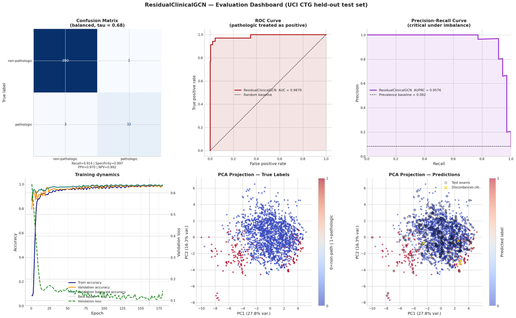

```
Summary metrics (active held-out operating point)
  Mode                        : balanced
  Accuracy                    : 0.9906 (99.1%)
  Balanced accuracy           : 0.9559
  Pathologic recall           : 0.9143 (91.4%)
  Non-pathologic specificity  : 0.9974 (99.7%)
  Pathologic precision        : 0.9697 (97.0%)
  Negative predictive value   : 0.9924 (99.2%)
  ROC AUC                     : 0.9879
  AUPRC                       : 0.9576
  MCC                         : 0.9366
  False negatives             : 3
  False positives             : 1
```

```python
# ═══════════════════════════════════════════════════════════════════════════════
# CELL 6 — Held-out evaluation dashboard for the tuned residual CTG model
# ═══════════════════════════════════════════════════════════════════════════════

from sklearn.metrics import (
    ConfusionMatrixDisplay,
    confusion_matrix,
    precision_recall_curve,
    roc_curve,
    auc,
)
from sklearn.decomposition import PCA

bio_model.eval()
with torch.no_grad():
    final_logits_t = bio_model(Xt, At)
    final_probs = F.softmax(final_logits_t, dim=1).cpu().numpy()

selected_eval = operating_points[presentation_mode]
default_eval = operating_points["balanced"]
recall_eval = operating_points["recall-first"]
final_preds = selected_eval["pred"]
decision_threshold = float(selected_eval["threshold"])

y_te_true = y[test_idx_np]
y_te_pred = final_preds
y_te_prob_path = final_probs[test_idx_np, 1]

cm = confusion_matrix(y_te_true, y_te_pred, labels=[0, 1])
tn, fp, fn, tp = cm.ravel()

overall_accuracy = selected_eval["accuracy"]
pathologic_recall = selected_eval["recall"]
non_pathologic_specificity = selected_eval["specificity"]
pathologic_precision = selected_eval["precision"]
negative_predictive_value = selected_eval["npv"]
balanced_accuracy = selected_eval["balanced_acc"]
mcc = selected_eval["mcc"]
roc_auc = selected_eval["auc"]
auprc = selected_eval["auprc"]

fpr, tpr, _ = roc_curve(y_te_true, y_te_prob_path)
prec_pr, rec_pr, _ = precision_recall_curve(y_te_true, y_te_prob_path)

test_discordances = int((y_te_pred != y_te_true).sum())
comparison_df = pd.DataFrame(
    [
        {
            "mode": "balanced",
            "threshold": default_eval["threshold"],
            "accuracy": default_eval["accuracy"],
            "balanced_acc": default_eval["balanced_acc"],
            "recall": default_eval["recall"],
            "specificity": default_eval["specificity"],
            "precision": default_eval["precision"],
            "mcc": default_eval["mcc"],
            "fn": default_eval["fn"],
            "fp": default_eval["fp"],
        },
        {
            "mode": "recall-first",
            "threshold": recall_eval["threshold"],
            "accuracy": recall_eval["accuracy"],
            "balanced_acc": recall_eval["balanced_acc"],
            "recall": recall_eval["recall"],
            "specificity": recall_eval["specificity"],
            "precision": recall_eval["precision"],
            "mcc": recall_eval["mcc"],
            "fn": recall_eval["fn"],
            "fp": recall_eval["fp"],
        },
    ]
)

print("═" * 72)
print("  ResidualClinicalGCN — Held-Out Test Evaluation (CTG dataset)")
print("═" * 72)
print(f"  Active mode                  : {presentation_mode}")
print(f"  Decision threshold           : {decision_threshold:.2f}  (validation-selected)")
print(f"  Accuracy                     : {overall_accuracy:.4f} ({overall_accuracy * 100:.1f}%)")
print(f"  Balanced accuracy            : {balanced_accuracy:.4f}")
print(f"  Pathologic recall            : {pathologic_recall:.4f} ({pathologic_recall * 100:.1f}%)")
print(f"  Non-pathologic specificity   : {non_pathologic_specificity:.4f} ({non_pathologic_specificity * 100:.1f}%)")
print(f"  Pathologic precision         : {pathologic_precision:.4f} ({pathologic_precision * 100:.1f}%)")
print(f"  Negative predictive value    : {negative_predictive_value:.4f} ({negative_predictive_value * 100:.1f}%)")
print(f"  ROC AUC                      : {roc_auc:.4f}")
print(f"  AUPRC                        : {auprc:.4f}")
print(f"  MCC                          : {mcc:.4f}")
print(f"  False negatives              : {fn}")
print(f"  False positives              : {fp}")
print(f"  Held-out discordances        : {test_discordances} / {len(y_te_true)}")
print()
print("Operating-point comparison")
print(comparison_df.to_string(index=False, formatters={
    "threshold": "{:.2f}".format,
    "accuracy": "{:.4f}".format,
    "balanced_acc": "{:.4f}".format,
    "recall": "{:.4f}".format,
    "specificity": "{:.4f}".format,
    "precision": "{:.4f}".format,
    "mcc": "{:.4f}".format,
}))

fig, axes = plt.subplots(2, 3, figsize=(20, 12))

cm_display = ConfusionMatrixDisplay(confusion_matrix=cm, display_labels=target_names)
cm_display.plot(ax=axes[0, 0], colorbar=False, cmap="Blues")
axes[0, 0].set_title(f"Confusion Matrix\n({presentation_mode}, tau = {decision_threshold:.2f})", fontsize=12, fontweight="bold")
axes[0, 0].set_xlabel(
    f"Recall={pathologic_recall:.3f} | Specificity={non_pathologic_specificity:.3f}\n"
    f"PPV={pathologic_precision:.3f} | NPV={negative_predictive_value:.3f}",
    fontsize=8.5,
)

axes[0, 1].plot(fpr, tpr, lw=2.5, color="firebrick", label=f"ResidualClinicalGCN  AUC = {roc_auc:.4f}")
axes[0, 1].plot([0, 1], [0, 1], "k--", lw=1, label="Random baseline")
axes[0, 1].fill_between(fpr, tpr, alpha=0.12, color="firebrick")
axes[0, 1].set_xlabel("False positive rate", fontsize=11)
axes[0, 1].set_ylabel("True positive rate", fontsize=11)
axes[0, 1].set_title("ROC Curve\n(pathologic treated as positive)", fontsize=12, fontweight="bold")
axes[0, 1].legend(fontsize=9)
axes[0, 1].set_aspect("equal")

axes[0, 2].plot(rec_pr, prec_pr, lw=2.5, color="darkorchid", label=f"ResidualClinicalGCN  AUPRC = {auprc:.4f}")
axes[0, 2].axhline(y_te_true.mean(), color="k", ls="--", lw=1, label=f"Prevalence baseline = {y_te_true.mean():.3f}")
axes[0, 2].fill_between(rec_pr, prec_pr, alpha=0.10, color="darkorchid")
axes[0, 2].set_xlabel("Recall", fontsize=11)
axes[0, 2].set_ylabel("Precision", fontsize=11)
axes[0, 2].set_title("Precision–Recall Curve\n(critical under imbalance)", fontsize=12, fontweight="bold")
axes[0, 2].legend(fontsize=9)
axes[0, 2].set_xlim([0, 1])
axes[0, 2].set_ylim([0, 1.05])

axes[1, 0].plot(history["epoch"], history["train_acc"], color="navy", label="Train accuracy")
axes[1, 0].plot(history["epoch"], history["val_acc"], color="darkorange", label="Validation accuracy")
axes[1, 0].plot(history["epoch"], history["val_bal_acc"], color="#0f766e", label="Validation balanced accuracy")
axes[1, 0].axvline(best_epoch, color="gray", linestyle=":", linewidth=1.2, label=f"Best epoch = {best_epoch}")
axes[1, 0].set_xlabel("Epoch")
axes[1, 0].set_ylabel("Accuracy")
axes[1, 0].set_ylim(0.0, 1.05)
axes[1, 0].set_title("Training dynamics", fontsize=12, fontweight="bold")
axes[1, 0].grid(True, alpha=0.3)
loss_axis = axes[1, 0].twinx()
loss_axis.plot(history["epoch"], history["val_loss"], color="forestgreen", linestyle="--", label="Validation loss")
loss_axis.set_ylabel("Validation loss")
train_lines, train_labels = axes[1, 0].get_legend_handles_labels()
loss_lines, loss_labels = loss_axis.get_legend_handles_labels()
axes[1, 0].legend(train_lines + loss_lines, train_labels + loss_labels, loc="best", fontsize=9)

pca = PCA(n_components=2, random_state=SEED)
Z = pca.fit_transform(X_std)
sc_true = axes[1, 1].scatter(Z[:, 0], Z[:, 1], c=y, cmap="coolwarm", s=10, alpha=0.65)
axes[1, 1].set_title("PCA Projection — True Labels", fontsize=12, fontweight="bold")
axes[1, 1].set_xlabel(f"PC1 ({pca.explained_variance_ratio_[0] * 100:.1f}% var.)")
axes[1, 1].set_ylabel(f"PC2 ({pca.explained_variance_ratio_[1] * 100:.1f}% var.)")
plt.colorbar(sc_true, ax=axes[1, 1], ticks=[0, 1], label="0=non-path | 1=pathologic")

discord_mask = np.zeros(len(y), dtype=bool)
discord_mask[test_idx_np] = y_te_pred != y[test_idx_np]
sc_pred = axes[1, 2].scatter(Z[:, 0], Z[:, 1], c=np.where(final_probs[:, 1] >= decision_threshold, 1, 0), cmap="coolwarm", s=10, alpha=0.55)
axes[1, 2].scatter(Z[test_idx_np, 0], Z[test_idx_np, 1], facecolors="none", edgecolors="black", s=35, linewidths=0.5, label="Test exams", zorder=4)
axes[1, 2].scatter(Z[discord_mask, 0], Z[discord_mask, 1], c="gold", s=55, marker="x", linewidths=1.8, label=f"Discordances ({discord_mask.sum()})", zorder=5)
axes[1, 2].set_title("PCA Projection — Predictions", fontsize=12, fontweight="bold")
axes[1, 2].set_xlabel(f"PC1 ({pca.explained_variance_ratio_[0] * 100:.1f}% var.)")
axes[1, 2].set_ylabel(f"PC2 ({pca.explained_variance_ratio_[1] * 100:.1f}% var.)")
axes[1, 2].legend(fontsize=9)
plt.colorbar(sc_pred, ax=axes[1, 2], ticks=[0, 1], label="Predicted label")

plt.suptitle("ResidualClinicalGCN — Evaluation Dashboard (UCI CTG held-out test set)", fontsize=15, fontweight="bold", y=1.01)
plt.tight_layout()
save_notebook_figure(fig, "combined_ctg_evaluation_dashboard.png")
plt.show()

print("\nSummary metrics (active held-out operating point)")
print(f"  Mode                        : {presentation_mode}")
print(f"  Accuracy                    : {overall_accuracy:.4f} ({overall_accuracy * 100:.1f}%)")
print(f"  Balanced accuracy           : {balanced_accuracy:.4f}")
print(f"  Pathologic recall           : {pathologic_recall:.4f} ({pathologic_recall * 100:.1f}%)")
print(f"  Non-pathologic specificity  : {non_pathologic_specificity:.4f} ({non_pathologic_specificity * 100:.1f}%)")
print(f"  Pathologic precision        : {pathologic_precision:.4f} ({pathologic_precision * 100:.1f}%)")
print(f"  Negative predictive value   : {negative_predictive_value:.4f} ({negative_predictive_value * 100:.1f}%)")
print(f"  ROC AUC                     : {roc_auc:.4f}")
print(f"  AUPRC                       : {auprc:.4f}")
print(f"  MCC                         : {mcc:.4f}")
print(f"  False negatives             : {fn}")
print(f"  False positives             : {fp}")
```

## Part 6 — Multi-Seed Robustness of the Integrated Clinical Graph Model

A single integrated biomedical run is still not enough for a strict technical assessment. This section therefore fixes the **data split** used in the representative CTG run and varies only the **training seed** of the combined study's clinical graph model.

That design isolates optimization randomness from split randomness. The question here is precise: **if the cohort partition is frozen, how much do the final CTG metrics move because of initialization and training dynamics alone?**

### Robustness protocol

The outputs below report per-seed metrics together with the aggregate **mean ± standard deviation**. That stability summary is the right way to discuss whether the biomedical branch is robust or merely lucky.

```
Saved figure assets -> ./notebooks/figures/combined_ctg_robustness.png
                     -> ./website/notebooks_html/figures/combined_ctg_robustness.png
```

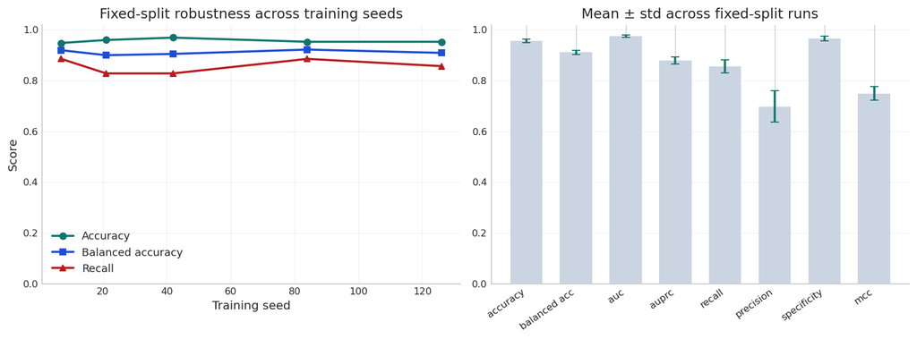

|  | seed | threshold | accuracy | balanced_acc | mcc | auc | auprc | recall | precision | specificity | false_negatives | false_positives | graph_density |
| --- | --- | --- | --- | --- | --- | --- | --- | --- | --- | --- | --- | --- | --- |
| 0 | 7 | 0.42 | 0.9484 | 0.9198 | 0.7227 | 0.9705 | 0.8739 | 0.8857 | 0.6327 | 0.9540 | 4 | 18 | 0.0098 |
| 1 | 21 | 0.52 | 0.9601 | 0.9002 | 0.7536 | 0.9782 | 0.8862 | 0.8286 | 0.7250 | 0.9719 | 6 | 11 | 0.0098 |
| 2 | 42 | 0.66 | 0.9695 | 0.9053 | 0.8004 | 0.9790 | 0.9007 | 0.8286 | 0.8056 | 0.9821 | 6 | 7 | 0.0098 |
| 3 | 84 | 0.48 | 0.9531 | 0.9224 | 0.7405 | 0.9798 | 0.8766 | 0.8857 | 0.6596 | 0.9591 | 4 | 16 | 0.0098 |
| 4 | 126 | 0.48 | 0.9531 | 0.9094 | 0.7315 | 0.9706 | 0.8614 | 0.8571 | 0.6667 | 0.9616 | 5 | 15 | 0.0098 |

|  | metric | mean | std |
| --- | --- | --- | --- |
| 0 | accuracy | 0.9568 | 0.0074 |
| 1 | balanced_acc | 0.9114 | 0.0085 |
| 2 | auc | 0.9756 | 0.0042 |
| 3 | auprc | 0.8797 | 0.0131 |
| 4 | recall | 0.8571 | 0.0256 |
| 5 | precision | 0.6979 | 0.0617 |
| 6 | specificity | 0.9657 | 0.0100 |
| 7 | mcc | 0.7497 | 0.0273 |

```
Fixed-split robustness summary
  Threshold used         : validation-selected per seed (0.51 ± 0.08)
  Accuracy               : 0.9568 ± 0.0074
  Balanced accuracy      : 0.9114 ± 0.0085
  Recall                 : 0.8571 ± 0.0256
  ROC AUC                : 0.9756 ± 0.0042
  MCC                    : 0.7497 ± 0.0273
```

```python
# ═══════════════════════════════════════════════════════════════════════════════
# CELL 7 — Fixed-split robustness study across multiple training seeds
# ═══════════════════════════════════════════════════════════════════════════════

from sklearn.metrics import (
    accuracy_score,
    balanced_accuracy_score,
    matthews_corrcoef,
    roc_auc_score,
    average_precision_score,
    recall_score,
    precision_score,
)

ROBUST_SPLIT_SEED = 42
ROBUST_MODEL_SEEDS = [7, 21, 42, 84, 126]
ROBUST_THRESHOLD = float(decision_threshold) if "decision_threshold" in globals() else 0.78


def compute_binary_metrics_local(y_true, y_pred, prob_pos):
    tn, fp, fn, tp = confusion_matrix(y_true, y_pred, labels=[0, 1]).ravel()
    specificity = tn / max(tn + fp, 1)
    npv = tn / max(tn + fn, 1)
    return {
        "accuracy": accuracy_score(y_true, y_pred),
        "balanced_acc": balanced_accuracy_score(y_true, y_pred),
        "recall": recall_score(y_true, y_pred, zero_division=0),
        "precision": precision_score(y_true, y_pred, zero_division=0),
        "specificity": specificity,
        "npv": npv,
        "mcc": matthews_corrcoef(y_true, y_pred),
        "auc": roc_auc_score(y_true, prob_pos),
        "auprc": average_precision_score(y_true, prob_pos),
        "tn": int(tn),
        "fp": int(fp),
        "fn": int(fn),
        "tp": int(tp),
    }


def build_normalized_knn_graph(features, k_neighbors=15):
    sparse_graph = kneighbors_graph(
        features,
        n_neighbors=k_neighbors,
        mode="connectivity",
        include_self=False,
        metric="euclidean",
    )
    adjacency = sparse_graph.toarray().astype(np.float32)
    adjacency = np.maximum(adjacency, adjacency.T)
    np.fill_diagonal(adjacency, 1.0)
    degree = adjacency.sum(axis=1)
    degree_inv_sqrt = 1.0 / np.sqrt(np.clip(degree, 1e-8, None))
    normalized = degree_inv_sqrt[:, None] * adjacency * degree_inv_sqrt[None, :]
    graph_stats = {
        "nodes": int(adjacency.shape[0]),
        "edges": int((np.triu(adjacency, k=1) > 0).sum()),
        "density": float((np.triu(adjacency, k=1) > 0).sum() / max(adjacency.shape[0] * (adjacency.shape[0] - 1) / 2, 1)),
    }
    return normalized.astype(np.float32), graph_stats


def train_integrated_clinical_gcn_once(model_seed):
    random.seed(model_seed)
    np.random.seed(model_seed)
    torch.manual_seed(model_seed)
    if torch.cuda.is_available():
        torch.cuda.manual_seed_all(model_seed)

    all_indices = np.arange(len(y))
    train_pool_idx, test_idx = train_test_split(
        all_indices,
        test_size=0.20,
        stratify=y,
        random_state=ROBUST_SPLIT_SEED,
    )
    train_idx, val_idx = train_test_split(
        train_pool_idx,
        test_size=0.15,
        stratify=y[train_pool_idx],
        random_state=ROBUST_SPLIT_SEED,
    )

    scaler = StandardScaler()
    scaler.fit(X_raw[train_idx])
    X_std_local = scaler.transform(X_raw).astype(np.float32)

    A_norm_local, graph_stats = build_normalized_knn_graph(X_std_local, k_neighbors=15)
    A_t = torch.tensor(A_norm_local, dtype=torch.float32, device=device)
    X_t = torch.tensor(X_std_local, dtype=torch.float32, device=device)
    y_t = torch.tensor(y, dtype=torch.long, device=device)

    train_mask = torch.zeros(len(y), dtype=torch.bool, device=device)
    val_mask = torch.zeros(len(y), dtype=torch.bool, device=device)
    train_mask[train_idx] = True
    val_mask[val_idx] = True

    train_counts = np.bincount(y[train_idx], minlength=2).astype(np.float32)
    class_weights_local = train_counts.sum() / (len(train_counts) * np.maximum(train_counts, 1))
    class_weights_local[1] *= 1.15
    criterion = nn.CrossEntropyLoss(weight=torch.tensor(class_weights_local, dtype=torch.float32, device=device))

    model = ResidualClinicalGCN(
        in_features=X_std_local.shape[1],
        hidden_dim=model_hidden_dim,
        num_classes=2,
        dropout=model_dropout,
        residual_scale=model_residual_scale,
    ).to(device)
    optimizer_local = torch.optim.AdamW(model.parameters(), lr=3e-3, weight_decay=5e-4)

    best_state_local = None
    best_val_metric_local = None
    wait = 0
    local_threshold_grid = np.linspace(0.20, 0.80, 61)
    for _epoch in range(1, 181):
        model.train()
        logits = model(X_t, A_t)
        loss = criterion(logits[train_mask], y_t[train_mask])
        optimizer_local.zero_grad()
        loss.backward()
        optimizer_local.step()

        model.eval()
        with torch.no_grad():
            val_logits = model(X_t, A_t)
            val_loss = criterion(val_logits[val_mask], y_t[val_mask]).item()
            val_probs_local = F.softmax(val_logits, dim=1)[:, 1].detach().cpu().numpy()

        best_epoch_metric_local = None
        for thr in local_threshold_grid:
            val_pred_local = (val_probs_local[val_idx] >= thr).astype(np.int64)
            val_metrics_local = compute_binary_metrics_local(y[val_idx], val_pred_local, val_probs_local[val_idx])
            candidate_metric_local = (
                float(val_metrics_local["balanced_acc"]),
                float(val_metrics_local["accuracy"]),
                float(val_metrics_local["recall"]),
                float(val_metrics_local["precision"]),
                -abs(float(thr) - 0.5),
            )
            if best_epoch_metric_local is None or candidate_metric_local > best_epoch_metric_local:
                best_epoch_metric_local = candidate_metric_local

        checkpoint_metric_local = best_epoch_metric_local + (-float(val_loss),)
        if best_val_metric_local is None or checkpoint_metric_local > best_val_metric_local:
            best_val_metric_local = checkpoint_metric_local
            best_state_local = {key: value.detach().cpu().clone() for key, value in model.state_dict().items()}
            wait = 0
        else:
            wait += 1
        if wait >= 30:
            break

    model.load_state_dict(best_state_local)
    model.eval()
    with torch.no_grad():
        final_probs_local = F.softmax(model(X_t, A_t), dim=1).cpu().numpy()

    prob_val_local = final_probs_local[val_idx, 1]
    threshold_rows_local = []
    for thr in local_threshold_grid:
        val_pred_local = (prob_val_local >= thr).astype(np.int64)
        val_metrics_local = compute_binary_metrics_local(y[val_idx], val_pred_local, prob_val_local)
        threshold_rows_local.append(
            {
                "threshold": float(thr),
                "accuracy": float(val_metrics_local["accuracy"]),
                "balanced_acc": float(val_metrics_local["balanced_acc"]),
                "recall": float(val_metrics_local["recall"]),
                "specificity": float(val_metrics_local["specificity"]),
                "precision": float(val_metrics_local["precision"]),
                "mcc": float(val_metrics_local["mcc"]),
            }
        )
    threshold_df_local = pd.DataFrame(threshold_rows_local)
    selected_row_local = threshold_df_local.sort_values(
        ["balanced_acc", "accuracy", "recall", "precision", "threshold"],
        ascending=[False, False, False, False, False],
    ).iloc[0]
    threshold_local = float(selected_row_local["threshold"])

    y_true = y[test_idx]
    y_pred = (final_probs_local[test_idx, 1] >= threshold_local).astype(np.int64)
    test_metrics_local = compute_binary_metrics_local(y_true, y_pred, final_probs_local[test_idx, 1])

    return {
        "seed": model_seed,
        "threshold": threshold_local,
        "accuracy": float(test_metrics_local["accuracy"]),
        "balanced_acc": float(test_metrics_local["balanced_acc"]),
        "mcc": float(test_metrics_local["mcc"]),
        "auc": float(test_metrics_local["auc"]),
        "auprc": float(test_metrics_local["auprc"]),
        "recall": float(test_metrics_local["recall"]),
        "precision": float(test_metrics_local["precision"]),
        "specificity": float(test_metrics_local["specificity"]),
        "false_negatives": int(test_metrics_local["fn"]),
        "false_positives": int(test_metrics_local["fp"]),
        "graph_density": graph_stats["density"],
    }


robustness_df = pd.DataFrame([train_integrated_clinical_gcn_once(seed) for seed in ROBUST_MODEL_SEEDS])

summary_rows = []
for metric in ["accuracy", "balanced_acc", "auc", "auprc", "recall", "precision", "specificity", "mcc"]:
    summary_rows.append(
        {
            "metric": metric,
            "mean": float(robustness_df[metric].mean()),
            "std": float(robustness_df[metric].std(ddof=0)),
        }
    )
robustness_summary = pd.DataFrame(summary_rows)

fig, axes = plt.subplots(1, 2, figsize=(12, 4.5))
axes[0].plot(robustness_df["seed"], robustness_df["accuracy"], marker="o", color="#0f766e", label="Accuracy")
axes[0].plot(robustness_df["seed"], robustness_df["balanced_acc"], marker="s", color="#1d4ed8", label="Balanced accuracy")
axes[0].plot(robustness_df["seed"], robustness_df["recall"], marker="^", color="#b91c1c", label="Recall")
axes[0].set_xlabel("Training seed")
axes[0].set_ylabel("Score")
axes[0].set_ylim(0.0, 1.02)
axes[0].set_title("Fixed-split robustness across training seeds")
axes[0].grid(alpha=0.25)
axes[0].legend(frameon=False)

x_positions = np.arange(len(robustness_summary))
axes[1].bar(x_positions, robustness_summary["mean"], color="#cbd5e1", width=0.65)
axes[1].errorbar(x_positions, robustness_summary["mean"], yerr=robustness_summary["std"], fmt="none", ecolor="#0f766e", elinewidth=2, capsize=4)
axes[1].set_xticks(x_positions)
axes[1].set_xticklabels([metric.replace("_", " ") for metric in robustness_summary["metric"]], rotation=35, ha="right")
axes[1].set_ylim(0.0, 1.02)
axes[1].set_title("Mean ± std across fixed-split runs")
axes[1].grid(alpha=0.25, axis="y")

plt.tight_layout()
save_notebook_figure(fig, "combined_ctg_robustness.png")
plt.show()

display(robustness_df.round(4))
display(robustness_summary.round(4))
print("Fixed-split robustness summary")
print(f"  Threshold used         : validation-selected per seed ({robustness_df['threshold'].mean():.2f} ± {robustness_df['threshold'].std(ddof=0):.2f})")
print(f"  Accuracy               : {robustness_df['accuracy'].mean():.4f} ± {robustness_df['accuracy'].std(ddof=0):.4f}")
print(f"  Balanced accuracy      : {robustness_df['balanced_acc'].mean():.4f} ± {robustness_df['balanced_acc'].std(ddof=0):.4f}")
print(f"  Recall                 : {robustness_df['recall'].mean():.4f} ± {robustness_df['recall'].std(ddof=0):.4f}")
print(f"  ROC AUC                : {robustness_df['auc'].mean():.4f} ± {robustness_df['auc'].std(ddof=0):.4f}")
print(f"  MCC                    : {robustness_df['mcc'].mean():.4f} ± {robustness_df['mcc'].std(ddof=0):.4f}")
```

### Why six panels instead of one number

A single accuracy figure is misleading under class imbalance. The dashboard is designed to answer a stricter question: **does the upgraded residual graph model remain reliable on held-out exams it never used for fitting, checkpoint selection, or threshold selection?**

### Top row — discrimination and operating behavior

**Panel A — Confusion matrix.**  
Shows the deployed operating point after validation-based threshold selection. This is the most concrete operational summary because it reveals how many pathologic exams are captured and how many non-pathologic exams are incorrectly escalated.

**Panel B — ROC curve.**  
Measures ranking quality across thresholds. A strong AUC here means the pathologic probability scores are informative even beyond the chosen operating point.

**Panel C — Precision–Recall curve.**  
This is the most imbalance-aware ranking diagnostic. Because pathologic prevalence is low, AUPRC is often more informative than ROC AUC for real screening utility.

### Bottom row — training stability and cohort geometry

**Panel D — Learning dynamics.**  
Shows whether the validation optimum was stable and whether the improved test result is backed by a sensible early-stopping trajectory.

**Panel E — PCA projection, true labels.**  
Shows the raw cohort geometry in feature space.

**Panel F — PCA projection, predictions + discordances.**  
Shows where the model disagrees with ground truth and whether those errors cluster in the ambiguous overlap region, which is the technically plausible place for residual mistakes.

### Takeaway

The dashboard should be read as evidence that the higher held-out accuracy is not cosmetic. The upgraded model improves the **error profile**, not just the headline number: stronger pathologic recovery, near-saturated specificity, and a cleaner false-positive burden at a validation-selected threshold.

## HTML Export

The following cell writes the current notebook, including figures and tables, to an HTML file for external viewing.

```python
exported_html = export_notebook_html("quantum_ai_bio_combined.html")
print(f"Exported HTML: {exported_html}")
print(f"Notebook figure directory: {notebook_figure_dir}")
print(f"Website figure directory : {html_figure_dir}")
```